# Python Project - (Prosper Loan Analysis)

## by (Ndivhuwo Netshiendeulu)

## Introduction

> The dataset contains details of the Prosper Loan customers or borrowers. This dataset has 113937 rows and 81 columns. Proper loan is a lending company that offers loans to various borrowers and investment options for investors. Borrowers apply money for personal loans and credit cards. The dataset shows details about the loans from the listing data to origination date and also the closed date. This dataset will be cleaned, analysed and visualized.

## Preliminary Wrangling

```python
# import all packages
import numpy as np
import pandas as pd
import matplotlib.pyplot as plt
import seaborn as sns
```

```python
#Load the dataset

df = pd.read_csv('Prosper Loan.csv')
```

```python
df
```

|  | ListingKey | ListingNumber | ListingCreationDate | CreditGrade | Term | LoanStatus | ClosedDate | BorrowerAPR | BorrowerRate | LenderYield | ... | LP_ServiceFees | LP_CollectionFees | LP_GrossPrincipalLoss | LP_NetPrincipalLoss | LP_NonPrincipalRecoverypayments | PercentFunded | Recommendations | InvestmentFromFriendsCount | InvestmentFromFriendsAmount | Investors |
| --- | --- | --- | --- | --- | --- | --- | --- | --- | --- | --- | --- | --- | --- | --- | --- | --- | --- | --- | --- | --- | --- |
| 0 | 1021339766868145413AB3B | 193129 | 09:29.3 | C | 36 | Completed | 14/08/2009 00:00 | 0.16516 | 0.1580 | 0.1380 | ... | -133.18 | 0.0 | 0.0 | 0.0 | 0.0 | 1.0 | 0 | 0 | 0.0 | 258 |
| 1 | 10273602499503308B223C1 | 1209647 | 28:07.9 | NaN | 36 | Current | NaN | 0.12016 | 0.0920 | 0.0820 | ... | 0.00 | 0.0 | 0.0 | 0.0 | 0.0 | 1.0 | 0 | 0 | 0.0 | 1 |
| 2 | 0EE9337825851032864889A | 81716 | 00:47.1 | HR | 36 | Completed | 17/12/2009 00:00 | 0.28269 | 0.2750 | 0.2400 | ... | -24.20 | 0.0 | 0.0 | 0.0 | 0.0 | 1.0 | 0 | 0 | 0.0 | 41 |
| 3 | 0EF5356002482715299901A | 658116 | 02:35.0 | NaN | 36 | Current | NaN | 0.12528 | 0.0974 | 0.0874 | ... | -108.01 | 0.0 | 0.0 | 0.0 | 0.0 | 1.0 | 0 | 0 | 0.0 | 158 |
| 4 | 0F023589499656230C5E3E2 | 909464 | 38:39.1 | NaN | 36 | Current | NaN | 0.24614 | 0.2085 | 0.1985 | ... | -60.27 | 0.0 | 0.0 | 0.0 | 0.0 | 1.0 | 0 | 0 | 0.0 | 20 |
| ... | ... | ... | ... | ... | ... | ... | ... | ... | ... | ... | ... | ... | ... | ... | ... | ... | ... | ... | ... | ... | ... |
| 113932 | E6D9357655724827169606C | 753087 | 55:02.7 | NaN | 36 | Current | NaN | 0.22354 | 0.1864 | 0.1764 | ... | -75.58 | 0.0 | 0.0 | 0.0 | 0.0 | 1.0 | 0 | 0 | 0.0 | 1 |
| 113933 | E6DB353036033497292EE43 | 537216 | 42:55.3 | NaN | 36 | FinalPaymentInProgress | NaN | 0.13220 | 0.1110 | 0.1010 | ... | -30.05 | 0.0 | 0.0 | 0.0 | 0.0 | 1.0 | 0 | 0 | 0.0 | 22 |
| 113934 | E6E13596170052029692BB1 | 1069178 | 49:12.7 | NaN | 60 | Current | NaN | 0.23984 | 0.2150 | 0.2050 | ... | -16.91 | 0.0 | 0.0 | 0.0 | 0.0 | 1.0 | 0 | 0 | 0.0 | 119 |
| 113935 | E6EB3531504622671970D9E | 539056 | 18:26.6 | NaN | 60 | Completed | 13/08/2013 00:00 | 0.28408 | 0.2605 | 0.2505 | ... | -235.05 | 0.0 | 0.0 | 0.0 | 0.0 | 1.0 | 0 | 0 | 0.0 | 274 |
| 113936 | E6ED3600409833199F711B7 | 1140093 | 27:37.7 | NaN | 36 | Current | NaN | 0.13189 | 0.1039 | 0.0939 | ... | -1.70 | 0.0 | 0.0 | 0.0 | 0.0 | 1.0 | 0 | 0 | 0.0 | 1 |

113937 rows × 81 columns

### Structure of the dataset

```python
# Check the structure of the dataset

type(df)
```

```
pandas.core.frame.DataFrame
```

### See the information in the dataset

```python
#See a summary of the dataset

df.info()
```

```
<class 'pandas.core.frame.DataFrame'>
RangeIndex: 113937 entries, 0 to 113936
Data columns (total 81 columns):
 #   Column                               Non-Null Count   Dtype
---  ------                               --------------   -----
 0   ListingKey                           113937 non-null  object
 1   ListingNumber                        113937 non-null  int64
 2   ListingCreationDate                  113937 non-null  object
 3   CreditGrade                          28953 non-null   object
 4   Term                                 113937 non-null  int64
 5   LoanStatus                           113937 non-null  object
 6   ClosedDate                           55089 non-null   object
 7   BorrowerAPR                          113912 non-null  float64
 8   BorrowerRate                         113937 non-null  float64
 9   LenderYield                          113937 non-null  float64
```

[output cut: 73 more lines]

```python
# See the number of rows and columns in the dataset

df.shape
```

```
(113937, 81)
```

```python
# Check for null rows in the first top 41 rows

df.isnull().sum().head(41)
```

```
ListingKey                          0
ListingNumber                       0
ListingCreationDate                 0
CreditGrade                     84984
Term                                0
LoanStatus                          0
ClosedDate                      58848
BorrowerAPR                        25
BorrowerRate                        0
LenderYield                         0
EstimatedEffectiveYield         29084
EstimatedLoss                   29084
EstimatedReturn                 29084
ProsperRating (numeric)         29084
ProsperRating (Alpha)           29084
ProsperScore                    29084
ListingCategory (numeric)           0
BorrowerState                    5515
Occupation                       3588
EmploymentStatus                 2255
EmploymentStatusDuration         7625
IsBorrowerHomeowner                 0
CurrentlyInGroup                    0
GroupKey                       100596
DateCreditPulled                    0
CreditScoreRangeLower             591
CreditScoreRangeUpper             591
FirstRecordedCreditLine           697
CurrentCreditLines               7604
OpenCreditLines                  7604
TotalCreditLinespast7years        697
OpenRevolvingAccounts               0
OpenRevolvingMonthlyPayment         0
InquiriesLast6Months              697
TotalInquiries                   1159
CurrentDelinquencies              697
AmountDelinquent                 7622
DelinquenciesLast7Years           990
PublicRecordsLast10Years          697
PublicRecordsLast12Months        7604
RevolvingCreditBalance           7604
dtype: int64
```

```python
# Check for null rows in the bottom 41 rows

df.isnull().sum().tail(41)
```

```
RevolvingCreditBalance                  7604
BankcardUtilization                     7604
AvailableBankcardCredit                 7544
TotalTrades                             7544
TradesNeverDelinquent (percentage)      7544
TradesOpenedLast6Months                 7544
DebtToIncomeRatio                       8554
IncomeRange                                0
IncomeVerifiable                           0
StatedMonthlyIncome                        0
LoanKey                                    0
TotalProsperLoans                      91852
TotalProsperPaymentsBilled             91852
OnTimeProsperPayments                  91852
ProsperPaymentsLessThanOneMonthLate    91852
ProsperPaymentsOneMonthPlusLate        91852
ProsperPrincipalBorrowed               91852
ProsperPrincipalOutstanding            91852
ScorexChangeAtTimeOfListing            95009
LoanCurrentDaysDelinquent                  0
LoanFirstDefaultedCycleNumber          96985
LoanMonthsSinceOrigination                 0
LoanNumber                                 0
LoanOriginalAmount                         0
LoanOriginationDate                        0
LoanOriginationQuarter                     0
MemberKey                                  0
MonthlyLoanPayment                         0
LP_CustomerPayments                        0
LP_CustomerPrincipalPayments               0
LP_InterestandFees                         0
LP_ServiceFees                             0
LP_CollectionFees                          0
LP_GrossPrincipalLoss                      0
LP_NetPrincipalLoss                        0
LP_NonPrincipalRecoverypayments            0
PercentFunded                              0
Recommendations                            0
InvestmentFromFriendsCount                 0
InvestmentFromFriendsAmount                0
Investors                                  0
dtype: int64
```

```python
#See the information in Columns 1,3,13,14

df.iloc[:,[1,3,13,14]]
```

|  | ListingNumber | CreditGrade | ProsperRating (numeric) | ProsperRating (Alpha) |
| --- | --- | --- | --- | --- |
| 0 | 193129 | C | NaN | NaN |
| 1 | 1209647 | NaN | 6.0 | A |
| 2 | 81716 | HR | NaN | NaN |
| 3 | 658116 | NaN | 6.0 | A |
| 4 | 909464 | NaN | 3.0 | D |
| ... | ... | ... | ... | ... |
| 113932 | 753087 | NaN | 4.0 | C |
| 113933 | 537216 | NaN | 6.0 | A |
| 113934 | 1069178 | NaN | 3.0 | D |
| 113935 | 539056 | NaN | 4.0 | C |
| 113936 | 1140093 | NaN | 6.0 | A |

113937 rows × 4 columns

### Create a new column called LoanRating, by concatenating the CreditGrade and ProsperRating(Alpha)

```python
#Rename the column ProsperRating (Alpha) to ProsperRating(Alpha)

df.rename(columns = {'ProsperRating (Alpha)': 'ProsperRating(Alpha)'},inplace=True)
```

```python
df.iloc[:,[1,3,13,14]]
```

|  | ListingNumber | CreditGrade | ProsperRating (numeric) | ProsperRating(Alpha) |
| --- | --- | --- | --- | --- |
| 0 | 193129 | C | NaN | NaN |
| 1 | 1209647 | NaN | 6.0 | A |
| 2 | 81716 | HR | NaN | NaN |
| 3 | 658116 | NaN | 6.0 | A |
| 4 | 909464 | NaN | 3.0 | D |
| ... | ... | ... | ... | ... |
| 113932 | 753087 | NaN | 4.0 | C |
| 113933 | 537216 | NaN | 6.0 | A |
| 113934 | 1069178 | NaN | 3.0 | D |
| 113935 | 539056 | NaN | 4.0 | C |
| 113936 | 1140093 | NaN | 6.0 | A |

113937 rows × 4 columns

```python
#Create the new column: LoanRating by combining CreditGrade and ProsperRating(Alpha), Use fillna()

df['LoanRating'] = df['CreditGrade'].fillna(df['ProsperRating(Alpha)'])
```

```python
df
```

|  | ListingKey | ListingNumber | ListingCreationDate | CreditGrade | Term | LoanStatus | ClosedDate | BorrowerAPR | BorrowerRate | LenderYield | ... | LP_CollectionFees | LP_GrossPrincipalLoss | LP_NetPrincipalLoss | LP_NonPrincipalRecoverypayments | PercentFunded | Recommendations | InvestmentFromFriendsCount | InvestmentFromFriendsAmount | Investors | LoanRating |
| --- | --- | --- | --- | --- | --- | --- | --- | --- | --- | --- | --- | --- | --- | --- | --- | --- | --- | --- | --- | --- | --- |
| 0 | 1021339766868145413AB3B | 193129 | 09:29.3 | C | 36 | Completed | 14/08/2009 00:00 | 0.16516 | 0.1580 | 0.1380 | ... | 0.0 | 0.0 | 0.0 | 0.0 | 1.0 | 0 | 0 | 0.0 | 258 | C |
| 1 | 10273602499503308B223C1 | 1209647 | 28:07.9 | NaN | 36 | Current | NaN | 0.12016 | 0.0920 | 0.0820 | ... | 0.0 | 0.0 | 0.0 | 0.0 | 1.0 | 0 | 0 | 0.0 | 1 | A |
| 2 | 0EE9337825851032864889A | 81716 | 00:47.1 | HR | 36 | Completed | 17/12/2009 00:00 | 0.28269 | 0.2750 | 0.2400 | ... | 0.0 | 0.0 | 0.0 | 0.0 | 1.0 | 0 | 0 | 0.0 | 41 | HR |
| 3 | 0EF5356002482715299901A | 658116 | 02:35.0 | NaN | 36 | Current | NaN | 0.12528 | 0.0974 | 0.0874 | ... | 0.0 | 0.0 | 0.0 | 0.0 | 1.0 | 0 | 0 | 0.0 | 158 | A |
| 4 | 0F023589499656230C5E3E2 | 909464 | 38:39.1 | NaN | 36 | Current | NaN | 0.24614 | 0.2085 | 0.1985 | ... | 0.0 | 0.0 | 0.0 | 0.0 | 1.0 | 0 | 0 | 0.0 | 20 | D |
| ... | ... | ... | ... | ... | ... | ... | ... | ... | ... | ... | ... | ... | ... | ... | ... | ... | ... | ... | ... | ... | ... |
| 113932 | E6D9357655724827169606C | 753087 | 55:02.7 | NaN | 36 | Current | NaN | 0.22354 | 0.1864 | 0.1764 | ... | 0.0 | 0.0 | 0.0 | 0.0 | 1.0 | 0 | 0 | 0.0 | 1 | C |
| 113933 | E6DB353036033497292EE43 | 537216 | 42:55.3 | NaN | 36 | FinalPaymentInProgress | NaN | 0.13220 | 0.1110 | 0.1010 | ... | 0.0 | 0.0 | 0.0 | 0.0 | 1.0 | 0 | 0 | 0.0 | 22 | A |
| 113934 | E6E13596170052029692BB1 | 1069178 | 49:12.7 | NaN | 60 | Current | NaN | 0.23984 | 0.2150 | 0.2050 | ... | 0.0 | 0.0 | 0.0 | 0.0 | 1.0 | 0 | 0 | 0.0 | 119 | D |
| 113935 | E6EB3531504622671970D9E | 539056 | 18:26.6 | NaN | 60 | Completed | 13/08/2013 00:00 | 0.28408 | 0.2605 | 0.2505 | ... | 0.0 | 0.0 | 0.0 | 0.0 | 1.0 | 0 | 0 | 0.0 | 274 | C |
| 113936 | E6ED3600409833199F711B7 | 1140093 | 27:37.7 | NaN | 36 | Current | NaN | 0.13189 | 0.1039 | 0.0939 | ... | 0.0 | 0.0 | 0.0 | 0.0 | 1.0 | 0 | 0 | 0.0 | 1 | A |

113937 rows × 82 columns

### Create a new column called IncomeRangeClass, based on the IncomeRange and StatedMonthlyIncome

```python
# See the information for IncomeRange and StatedMonthlyIncome

df.iloc[:,[47,49]]
```

|  | IncomeRange | StatedMonthlyIncome |
| --- | --- | --- |
| 0 | $25,000-49,999 | 3083.333333 |
| 1 | $50,000-74,999 | 6125.000000 |
| 2 | Not displayed | 2083.333333 |
| 3 | $25,000-49,999 | 2875.000000 |
| 4 | $100,000+ | 9583.333333 |
| ... | ... | ... |
| 113932 | $50,000-74,999 | 4333.333333 |
| 113933 | $75,000-99,999 | 8041.666667 |
| 113934 | $25,000-49,999 | 2875.000000 |
| 113935 | $25,000-49,999 | 3875.000000 |
| 113936 | $50,000-74,999 | 4583.333333 |

113937 rows × 2 columns

```python
# Inset a new column called IncomeRangeClass based on the StatedMonthlyIncome and using conditions on the IncomeRange and the StatedMonthlyIncome
#First set the conditions and the values for if the condition is met

conditions = [
    (df['StatedMonthlyIncome'] <=24999),
    (df['StatedMonthlyIncome'] > 24999) & (df['StatedMonthlyIncome'] <= 49999),
    (df['StatedMonthlyIncome'] > 49999) & (df['StatedMonthlyIncome'] <= 74999),
    (df['StatedMonthlyIncome'] > 74999) & (df['StatedMonthlyIncome'] <= 99999),
    (df['StatedMonthlyIncome'] > 99999)
    ]
# create a list of the values we want to assign for each condition
values = ['Poor', 'LowerMiddleClass', 'MiddleClass', 'UpperMiddleClass','Rich']

# create a new column and use np.select to assign values to it using our lists as arguments
df['IncomeRangeClass'] = np.select(conditions, values)

# display the first top 5 updated DataFrame
df.head()
```

|  | ListingKey | ListingNumber | ListingCreationDate | CreditGrade | Term | LoanStatus | ClosedDate | BorrowerAPR | BorrowerRate | LenderYield | ... | LP_GrossPrincipalLoss | LP_NetPrincipalLoss | LP_NonPrincipalRecoverypayments | PercentFunded | Recommendations | InvestmentFromFriendsCount | InvestmentFromFriendsAmount | Investors | LoanRating | IncomeRangeClass |
| --- | --- | --- | --- | --- | --- | --- | --- | --- | --- | --- | --- | --- | --- | --- | --- | --- | --- | --- | --- | --- | --- |
| 0 | 1021339766868145413AB3B | 193129 | 09:29.3 | C | 36 | Completed | 14/08/2009 00:00 | 0.16516 | 0.1580 | 0.1380 | ... | 0.0 | 0.0 | 0.0 | 1.0 | 0 | 0 | 0.0 | 258 | C | Poor |
| 1 | 10273602499503308B223C1 | 1209647 | 28:07.9 | NaN | 36 | Current | NaN | 0.12016 | 0.0920 | 0.0820 | ... | 0.0 | 0.0 | 0.0 | 1.0 | 0 | 0 | 0.0 | 1 | A | Poor |
| 2 | 0EE9337825851032864889A | 81716 | 00:47.1 | HR | 36 | Completed | 17/12/2009 00:00 | 0.28269 | 0.2750 | 0.2400 | ... | 0.0 | 0.0 | 0.0 | 1.0 | 0 | 0 | 0.0 | 41 | HR | Poor |
| 3 | 0EF5356002482715299901A | 658116 | 02:35.0 | NaN | 36 | Current | NaN | 0.12528 | 0.0974 | 0.0874 | ... | 0.0 | 0.0 | 0.0 | 1.0 | 0 | 0 | 0.0 | 158 | A | Poor |
| 4 | 0F023589499656230C5E3E2 | 909464 | 38:39.1 | NaN | 36 | Current | NaN | 0.24614 | 0.2085 | 0.1985 | ... | 0.0 | 0.0 | 0.0 | 1.0 | 0 | 0 | 0.0 | 20 | D | Poor |

5 rows × 83 columns

```python
#See a summary of the dataset

df.info()
```

```
<class 'pandas.core.frame.DataFrame'>
RangeIndex: 113937 entries, 0 to 113936
Data columns (total 83 columns):
 #   Column                               Non-Null Count   Dtype
---  ------                               --------------   -----
 0   ListingKey                           113937 non-null  object
 1   ListingNumber                        113937 non-null  int64
 2   ListingCreationDate                  113937 non-null  object
 3   CreditGrade                          28953 non-null   object
 4   Term                                 113937 non-null  int64
 5   LoanStatus                           113937 non-null  object
 6   ClosedDate                           55089 non-null   object
 7   BorrowerAPR                          113912 non-null  float64
 8   BorrowerRate                         113937 non-null  float64
 9   LenderYield                          113937 non-null  float64
```

[output cut: 75 more lines]

### Drop columns

```python
#drop columns

df.drop(['EstimatedEffectiveYield', 'EstimatedLoss','CurrentCreditLines','IncomeRange','CreditGrade','ProsperRating(Alpha)','TotalProsperPaymentsBilled','ProsperPaymentsOneMonthPlusLate'],inplace=True, axis=1)
```

```python
df
```

|  | ListingKey | ListingNumber | ListingCreationDate | Term | LoanStatus | ClosedDate | BorrowerAPR | BorrowerRate | LenderYield | EstimatedReturn | ... | LP_GrossPrincipalLoss | LP_NetPrincipalLoss | LP_NonPrincipalRecoverypayments | PercentFunded | Recommendations | InvestmentFromFriendsCount | InvestmentFromFriendsAmount | Investors | LoanRating | IncomeRangeClass |
| --- | --- | --- | --- | --- | --- | --- | --- | --- | --- | --- | --- | --- | --- | --- | --- | --- | --- | --- | --- | --- | --- |
| 0 | 1021339766868145413AB3B | 193129 | 09:29.3 | 36 | Completed | 14/08/2009 00:00 | 0.16516 | 0.1580 | 0.1380 | NaN | ... | 0.0 | 0.0 | 0.0 | 1.0 | 0 | 0 | 0.0 | 258 | C | Poor |
| 1 | 10273602499503308B223C1 | 1209647 | 28:07.9 | 36 | Current | NaN | 0.12016 | 0.0920 | 0.0820 | 0.05470 | ... | 0.0 | 0.0 | 0.0 | 1.0 | 0 | 0 | 0.0 | 1 | A | Poor |
| 2 | 0EE9337825851032864889A | 81716 | 00:47.1 | 36 | Completed | 17/12/2009 00:00 | 0.28269 | 0.2750 | 0.2400 | NaN | ... | 0.0 | 0.0 | 0.0 | 1.0 | 0 | 0 | 0.0 | 41 | HR | Poor |
| 3 | 0EF5356002482715299901A | 658116 | 02:35.0 | 36 | Current | NaN | 0.12528 | 0.0974 | 0.0874 | 0.06000 | ... | 0.0 | 0.0 | 0.0 | 1.0 | 0 | 0 | 0.0 | 158 | A | Poor |
| 4 | 0F023589499656230C5E3E2 | 909464 | 38:39.1 | 36 | Current | NaN | 0.24614 | 0.2085 | 0.1985 | 0.09066 | ... | 0.0 | 0.0 | 0.0 | 1.0 | 0 | 0 | 0.0 | 20 | D | Poor |
| ... | ... | ... | ... | ... | ... | ... | ... | ... | ... | ... | ... | ... | ... | ... | ... | ... | ... | ... | ... | ... | ... |
| 113932 | E6D9357655724827169606C | 753087 | 55:02.7 | 36 | Current | NaN | 0.22354 | 0.1864 | 0.1764 | 0.09500 | ... | 0.0 | 0.0 | 0.0 | 1.0 | 0 | 0 | 0.0 | 1 | C | Poor |
| 113933 | E6DB353036033497292EE43 | 537216 | 42:55.3 | 36 | FinalPaymentInProgress | NaN | 0.13220 | 0.1110 | 0.1010 | 0.08070 | ... | 0.0 | 0.0 | 0.0 | 1.0 | 0 | 0 | 0.0 | 22 | A | Poor |
| 113934 | E6E13596170052029692BB1 | 1069178 | 49:12.7 | 60 | Current | NaN | 0.23984 | 0.2150 | 0.2050 | 0.08578 | ... | 0.0 | 0.0 | 0.0 | 1.0 | 0 | 0 | 0.0 | 119 | D | Poor |
| 113935 | E6EB3531504622671970D9E | 539056 | 18:26.6 | 60 | Completed | 13/08/2013 00:00 | 0.28408 | 0.2605 | 0.2505 | 0.15950 | ... | 0.0 | 0.0 | 0.0 | 1.0 | 0 | 0 | 0.0 | 274 | C | Poor |
| 113936 | E6ED3600409833199F711B7 | 1140093 | 27:37.7 | 36 | Current | NaN | 0.13189 | 0.1039 | 0.0939 | 0.06081 | ... | 0.0 | 0.0 | 0.0 | 1.0 | 0 | 0 | 0.0 | 1 | A | Poor |

113937 rows × 75 columns

```python
#See a summary of the dataset

df.info()
```

```
<class 'pandas.core.frame.DataFrame'>
RangeIndex: 113937 entries, 0 to 113936
Data columns (total 75 columns):
 #   Column                               Non-Null Count   Dtype
---  ------                               --------------   -----
 0   ListingKey                           113937 non-null  object
 1   ListingNumber                        113937 non-null  int64
 2   ListingCreationDate                  113937 non-null  object
 3   Term                                 113937 non-null  int64
 4   LoanStatus                           113937 non-null  object
 5   ClosedDate                           55089 non-null   object
 6   BorrowerAPR                          113912 non-null  float64
 7   BorrowerRate                         113937 non-null  float64
 8   LenderYield                          113937 non-null  float64
 9   EstimatedReturn                      84853 non-null   float64
```

[output cut: 67 more lines]

### Rename LoanRating to CreditRating

```python
#rename LoanRating to CreditRating

df.rename(columns = {'LoanRating':'CreditRating'}, inplace = True)
df
```

|  | ListingKey | ListingNumber | ListingCreationDate | Term | LoanStatus | ClosedDate | BorrowerAPR | BorrowerRate | LenderYield | EstimatedReturn | ... | LP_GrossPrincipalLoss | LP_NetPrincipalLoss | LP_NonPrincipalRecoverypayments | PercentFunded | Recommendations | InvestmentFromFriendsCount | InvestmentFromFriendsAmount | Investors | CreditRating | IncomeRangeClass |
| --- | --- | --- | --- | --- | --- | --- | --- | --- | --- | --- | --- | --- | --- | --- | --- | --- | --- | --- | --- | --- | --- |
| 0 | 1021339766868145413AB3B | 193129 | 09:29.3 | 36 | Completed | 14/08/2009 00:00 | 0.16516 | 0.1580 | 0.1380 | NaN | ... | 0.0 | 0.0 | 0.0 | 1.0 | 0 | 0 | 0.0 | 258 | C | Poor |
| 1 | 10273602499503308B223C1 | 1209647 | 28:07.9 | 36 | Current | NaN | 0.12016 | 0.0920 | 0.0820 | 0.05470 | ... | 0.0 | 0.0 | 0.0 | 1.0 | 0 | 0 | 0.0 | 1 | A | Poor |
| 2 | 0EE9337825851032864889A | 81716 | 00:47.1 | 36 | Completed | 17/12/2009 00:00 | 0.28269 | 0.2750 | 0.2400 | NaN | ... | 0.0 | 0.0 | 0.0 | 1.0 | 0 | 0 | 0.0 | 41 | HR | Poor |
| 3 | 0EF5356002482715299901A | 658116 | 02:35.0 | 36 | Current | NaN | 0.12528 | 0.0974 | 0.0874 | 0.06000 | ... | 0.0 | 0.0 | 0.0 | 1.0 | 0 | 0 | 0.0 | 158 | A | Poor |
| 4 | 0F023589499656230C5E3E2 | 909464 | 38:39.1 | 36 | Current | NaN | 0.24614 | 0.2085 | 0.1985 | 0.09066 | ... | 0.0 | 0.0 | 0.0 | 1.0 | 0 | 0 | 0.0 | 20 | D | Poor |
| ... | ... | ... | ... | ... | ... | ... | ... | ... | ... | ... | ... | ... | ... | ... | ... | ... | ... | ... | ... | ... | ... |
| 113932 | E6D9357655724827169606C | 753087 | 55:02.7 | 36 | Current | NaN | 0.22354 | 0.1864 | 0.1764 | 0.09500 | ... | 0.0 | 0.0 | 0.0 | 1.0 | 0 | 0 | 0.0 | 1 | C | Poor |
| 113933 | E6DB353036033497292EE43 | 537216 | 42:55.3 | 36 | FinalPaymentInProgress | NaN | 0.13220 | 0.1110 | 0.1010 | 0.08070 | ... | 0.0 | 0.0 | 0.0 | 1.0 | 0 | 0 | 0.0 | 22 | A | Poor |
| 113934 | E6E13596170052029692BB1 | 1069178 | 49:12.7 | 60 | Current | NaN | 0.23984 | 0.2150 | 0.2050 | 0.08578 | ... | 0.0 | 0.0 | 0.0 | 1.0 | 0 | 0 | 0.0 | 119 | D | Poor |
| 113935 | E6EB3531504622671970D9E | 539056 | 18:26.6 | 60 | Completed | 13/08/2013 00:00 | 0.28408 | 0.2605 | 0.2505 | 0.15950 | ... | 0.0 | 0.0 | 0.0 | 1.0 | 0 | 0 | 0.0 | 274 | C | Poor |
| 113936 | E6ED3600409833199F711B7 | 1140093 | 27:37.7 | 36 | Current | NaN | 0.13189 | 0.1039 | 0.0939 | 0.06081 | ... | 0.0 | 0.0 | 0.0 | 1.0 | 0 | 0 | 0.0 | 1 | A | Poor |

113937 rows × 75 columns

### Change Dates into Datetime

```python
#See columns with dates

df.iloc[:,[2,5,20,23,56]]
```

|  | ListingCreationDate | ClosedDate | DateCreditPulled | FirstRecordedCreditLine | LoanOriginationDate |
| --- | --- | --- | --- | --- | --- |
| 0 | 09:29.3 | 14/08/2009 00:00 | 41:46.8 | 11/10/2001 00:00 | 12/09/2007 00:00 |
| 1 | 28:07.9 | NaN | 27/02/2014 08:28 | 18/03/1996 00:00 | 03/03/2014 00:00 |
| 2 | 00:47.1 | 17/12/2009 00:00 | 09:10.1 | 27/07/2002 00:00 | 17/01/2007 00:00 |
| 3 | 02:35.0 | NaN | 22/10/2012 11:02 | 28/02/1983 00:00 | 01/11/2012 00:00 |
| 4 | 38:39.1 | NaN | 14/09/2013 18:38 | 20/02/2004 00:00 | 20/09/2013 00:00 |
| ... | ... | ... | ... | ... | ... |
| 113932 | 55:02.7 | NaN | 14/04/2013 05:54 | 01/09/1997 00:00 | 22/04/2013 00:00 |
| 113933 | 42:55.3 | NaN | 03/11/2011 20:42 | 17/01/1992 00:00 | 07/11/2011 00:00 |
| 113934 | 49:12.7 | NaN | 13/12/2013 05:49 | 25/02/2002 00:00 | 23/12/2013 00:00 |
| 113935 | 18:26.6 | 13/08/2013 00:00 | 14/11/2011 13:18 | 01/12/1993 00:00 | 21/11/2011 00:00 |
| 113936 | 27:37.7 | NaN | 15/01/2014 09:27 | 01/01/1995 00:00 | 21/01/2014 00:00 |

113937 rows × 5 columns

```python
#Change these dates from object type to Datetime format

df['ListingCreationDate']= pd.to_datetime(df['ListingCreationDate'], errors='coerce')
df['ClosedDate']= pd.to_datetime(df['ClosedDate'], errors='coerce')
df['DateCreditPulled']= pd.to_datetime(df['DateCreditPulled'], errors='coerce')
df['FirstRecordedCreditLine']= pd.to_datetime(df['FirstRecordedCreditLine'], errors='coerce')
df['LoanOriginationDate']= pd.to_datetime(df['LoanOriginationDate'],errors='coerce')
df
```

|  | ListingKey | ListingNumber | ListingCreationDate | Term | LoanStatus | ClosedDate | BorrowerAPR | BorrowerRate | LenderYield | EstimatedReturn | ... | LP_GrossPrincipalLoss | LP_NetPrincipalLoss | LP_NonPrincipalRecoverypayments | PercentFunded | Recommendations | InvestmentFromFriendsCount | InvestmentFromFriendsAmount | Investors | CreditRating | IncomeRangeClass |
| --- | --- | --- | --- | --- | --- | --- | --- | --- | --- | --- | --- | --- | --- | --- | --- | --- | --- | --- | --- | --- | --- |
| 0 | 1021339766868145413AB3B | 193129 | 2023-02-10 09:29:18 | 36 | Completed | 2009-08-14 | 0.16516 | 0.1580 | 0.1380 | NaN | ... | 0.0 | 0.0 | 0.0 | 1.0 | 0 | 0 | 0.0 | 258 | C | Poor |
| 1 | 10273602499503308B223C1 | 1209647 | NaT | 36 | Current | NaT | 0.12016 | 0.0920 | 0.0820 | 0.05470 | ... | 0.0 | 0.0 | 0.0 | 1.0 | 0 | 0 | 0.0 | 1 | A | Poor |
| 2 | 0EE9337825851032864889A | 81716 | 2023-02-10 00:47:06 | 36 | Completed | 2009-12-17 | 0.28269 | 0.2750 | 0.2400 | NaN | ... | 0.0 | 0.0 | 0.0 | 1.0 | 0 | 0 | 0.0 | 41 | HR | Poor |
| 3 | 0EF5356002482715299901A | 658116 | 2023-02-10 02:35:00 | 36 | Current | NaT | 0.12528 | 0.0974 | 0.0874 | 0.06000 | ... | 0.0 | 0.0 | 0.0 | 1.0 | 0 | 0 | 0.0 | 158 | A | Poor |
| 4 | 0F023589499656230C5E3E2 | 909464 | NaT | 36 | Current | NaT | 0.24614 | 0.2085 | 0.1985 | 0.09066 | ... | 0.0 | 0.0 | 0.0 | 1.0 | 0 | 0 | 0.0 | 20 | D | Poor |
| ... | ... | ... | ... | ... | ... | ... | ... | ... | ... | ... | ... | ... | ... | ... | ... | ... | ... | ... | ... | ... | ... |
| 113932 | E6D9357655724827169606C | 753087 | NaT | 36 | Current | NaT | 0.22354 | 0.1864 | 0.1764 | 0.09500 | ... | 0.0 | 0.0 | 0.0 | 1.0 | 0 | 0 | 0.0 | 1 | C | Poor |
| 113933 | E6DB353036033497292EE43 | 537216 | NaT | 36 | FinalPaymentInProgress | NaT | 0.13220 | 0.1110 | 0.1010 | 0.08070 | ... | 0.0 | 0.0 | 0.0 | 1.0 | 0 | 0 | 0.0 | 22 | A | Poor |
| 113934 | E6E13596170052029692BB1 | 1069178 | NaT | 60 | Current | NaT | 0.23984 | 0.2150 | 0.2050 | 0.08578 | ... | 0.0 | 0.0 | 0.0 | 1.0 | 0 | 0 | 0.0 | 119 | D | Poor |
| 113935 | E6EB3531504622671970D9E | 539056 | 2023-02-10 18:26:36 | 60 | Completed | 2013-08-13 | 0.28408 | 0.2605 | 0.2505 | 0.15950 | ... | 0.0 | 0.0 | 0.0 | 1.0 | 0 | 0 | 0.0 | 274 | C | Poor |
| 113936 | E6ED3600409833199F711B7 | 1140093 | NaT | 36 | Current | NaT | 0.13189 | 0.1039 | 0.0939 | 0.06081 | ... | 0.0 | 0.0 | 0.0 | 1.0 | 0 | 0 | 0.0 | 1 | A | Poor |

113937 rows × 75 columns

```python
#See columns with dates

df.iloc[:,[2,5,20,23,56]]
```

|  | ListingCreationDate | ClosedDate | DateCreditPulled | FirstRecordedCreditLine | LoanOriginationDate |
| --- | --- | --- | --- | --- | --- |
| 0 | 2023-02-10 09:29:18 | 2009-08-14 | NaT | 2001-11-10 | 2007-12-09 |
| 1 | NaT | NaT | 2014-02-27 08:28:00 | 1996-03-18 | 2014-03-03 |
| 2 | 2023-02-10 00:47:06 | 2009-12-17 | 2023-02-10 09:10:06 | 2002-07-27 | 2007-01-17 |
| 3 | 2023-02-10 02:35:00 | NaT | 2012-10-22 11:02:00 | 1983-02-28 | 2012-01-11 |
| 4 | NaT | NaT | 2013-09-14 18:38:00 | 2004-02-20 | 2013-09-20 |
| ... | ... | ... | ... | ... | ... |
| 113932 | NaT | NaT | 2013-04-14 05:54:00 | 1997-01-09 | 2013-04-22 |
| 113933 | NaT | NaT | 2011-03-11 20:42:00 | 1992-01-17 | 2011-07-11 |
| 113934 | NaT | NaT | 2013-12-13 05:49:00 | 2002-02-25 | 2013-12-23 |
| 113935 | 2023-02-10 18:26:36 | 2013-08-13 | 2011-11-14 13:18:00 | 1993-01-12 | 2011-11-21 |
| 113936 | NaT | NaT | 2014-01-15 09:27:00 | 1995-01-01 | 2014-01-21 |

113937 rows × 5 columns

```python
#See a summary of the dataset

df.info()
```

```
<class 'pandas.core.frame.DataFrame'>
RangeIndex: 113937 entries, 0 to 113936
Data columns (total 75 columns):
 #   Column                               Non-Null Count   Dtype
---  ------                               --------------   -----
 0   ListingKey                           113937 non-null  object
 1   ListingNumber                        113937 non-null  int64
 2   ListingCreationDate                  45425 non-null   datetime64[ns]
 3   Term                                 113937 non-null  int64
 4   LoanStatus                           113937 non-null  object
 5   ClosedDate                           55080 non-null   datetime64[ns]
 6   BorrowerAPR                          113912 non-null  float64
 7   BorrowerRate                         113937 non-null  float64
 8   LenderYield                          113937 non-null  float64
 9   EstimatedReturn                      84853 non-null   float64
```

[output cut: 67 more lines]

```python
#See first top 20 columns with dates

df.iloc[:,[2,5,20,23,56]].head(20)
```

|  | ListingCreationDate | ClosedDate | DateCreditPulled | FirstRecordedCreditLine | LoanOriginationDate |
| --- | --- | --- | --- | --- | --- |
| 0 | 2023-02-10 09:29:18 | 2009-08-14 | NaT | 2001-11-10 | 2007-12-09 |
| 1 | NaT | NaT | 2014-02-27 08:28:00 | 1996-03-18 | 2014-03-03 |
| 2 | 2023-02-10 00:47:06 | 2009-12-17 | 2023-02-10 09:10:06 | 2002-07-27 | 2007-01-17 |
| 3 | 2023-02-10 02:35:00 | NaT | 2012-10-22 11:02:00 | 1983-02-28 | 2012-01-11 |
| 4 | NaT | NaT | 2013-09-14 18:38:00 | 2004-02-20 | 2013-09-20 |
| 5 | NaT | NaT | 2013-12-14 08:26:00 | 1973-01-03 | 2013-12-24 |
| 6 | NaT | NaT | 2013-12-04 09:52:00 | 2000-09-29 | 2013-04-18 |
| 7 | NaT | NaT | 2013-05-05 06:49:00 | 1999-02-25 | 2013-05-13 |
| 8 | NaT | NaT | 2013-02-12 10:43:00 | 1993-01-04 | 2013-12-12 |
| 9 | NaT | NaT | 2013-02-12 10:43:00 | 1993-01-04 | 2013-12-12 |
| 10 | 2023-02-10 04:01:36 | NaT | 2012-04-22 08:38:00 | 1989-11-29 | 2012-05-17 |
| 11 | NaT | 2008-07-01 | 2023-02-10 13:44:24 | 2000-11-13 | 2007-10-18 |
| 12 | 2023-02-10 01:10:48 | NaT | 2013-12-15 20:01:00 | 1996-09-11 | 2014-07-01 |
| 13 | NaT | NaT | 2013-11-07 16:51:00 | 2007-03-20 | 2013-07-18 |
| 14 | 2023-02-10 17:41:42 | NaT | 2013-04-19 11:17:00 | 1992-06-07 | 2013-05-13 |
| 15 | 2023-02-10 14:46:18 | 2012-12-19 | 2012-10-04 09:14:00 | 1999-08-03 | 2012-04-19 |
| 16 | NaT | NaT | 2013-07-16 12:42:00 | 2001-11-08 | 2013-07-18 |
| 17 | 2023-02-10 21:09:24 | 2008-05-22 | NaT | 1990-05-19 | 2006-08-22 |
| 18 | NaT | NaT | 2013-02-20 03:48:00 | 1994-12-20 | 2013-11-03 |
| 19 | NaT | NaT | 2013-04-10 17:49:00 | 2007-08-13 | 2013-10-10 |

```python
#See last bottom columns with dates

df.iloc[:,[2,5,20,23,56]].tail(20)
```

|  | ListingCreationDate | ClosedDate | DateCreditPulled | FirstRecordedCreditLine | LoanOriginationDate |
| --- | --- | --- | --- | --- | --- |
| 113917 | NaT | NaT | 2013-11-23 04:52:00 | 1984-02-07 | 2013-11-29 |
| 113918 | 2023-02-10 02:53:18 | 2011-01-27 | 2023-02-10 02:10:30 | 1983-01-11 | 2008-06-27 |
| 113919 | NaT | NaT | 2013-07-05 18:49:00 | 1996-12-18 | 2013-05-14 |
| 113920 | NaT | NaT | 2013-11-06 05:49:00 | 1998-12-10 | 2013-06-13 |
| 113921 | NaT | 2005-11-25 | NaT | NaT | 2005-11-15 |
| 113922 | NaT | 2011-08-19 | NaT | 1999-06-23 | 2008-08-19 |
| 113923 | NaT | 2011-09-23 | NaT | 1997-03-19 | 2008-09-23 |
| 113924 | 2023-02-10 15:52:42 | NaT | 2012-10-20 19:15:00 | 2002-11-15 | 2012-10-23 |
| 113925 | NaT | NaT | 2013-04-25 06:58:00 | 1999-02-16 | 2013-08-05 |
| 113926 | NaT | 2007-06-09 | 2023-02-10 10:42:24 | 1996-03-26 | 2006-08-08 |
| 113927 | NaT | 2011-09-05 | 2023-02-10 20:54:36 | 1972-09-09 | 2008-09-05 |
| 113928 | 2023-02-10 02:44:24 | 2011-09-19 | 2011-03-06 16:06:00 | 2004-06-06 | 2011-10-06 |
| 113929 | NaT | 2014-07-02 | 2013-06-07 17:39:00 | 2008-11-17 | 2013-10-07 |
| 113930 | NaT | NaT | 2013-08-07 10:24:00 | 1999-12-20 | 2013-10-07 |
| 113931 | 2023-02-10 13:08:00 | NaT | 2014-03-01 10:17:00 | 1975-01-05 | 2014-01-22 |
| 113932 | NaT | NaT | 2013-04-14 05:54:00 | 1997-01-09 | 2013-04-22 |
| 113933 | NaT | NaT | 2011-03-11 20:42:00 | 1992-01-17 | 2011-07-11 |
| 113934 | NaT | NaT | 2013-12-13 05:49:00 | 2002-02-25 | 2013-12-23 |
| 113935 | 2023-02-10 18:26:36 | 2013-08-13 | 2011-11-14 13:18:00 | 1993-01-12 | 2011-11-21 |
| 113936 | NaT | NaT | 2014-01-15 09:27:00 | 1995-01-01 | 2014-01-21 |

```python
# Split the date column to date and time(hours), for ClosedDate

df['dateClosedDate'] = pd.to_datetime(df['ClosedDate']).dt.date
df['timeClosedDate'] = pd.to_datetime(df['ClosedDate']).dt.time
df
```

|  | ListingKey | ListingNumber | ListingCreationDate | Term | LoanStatus | ClosedDate | BorrowerAPR | BorrowerRate | LenderYield | EstimatedReturn | ... | LP_NonPrincipalRecoverypayments | PercentFunded | Recommendations | InvestmentFromFriendsCount | InvestmentFromFriendsAmount | Investors | CreditRating | IncomeRangeClass | dateClosedDate | timeClosedDate |
| --- | --- | --- | --- | --- | --- | --- | --- | --- | --- | --- | --- | --- | --- | --- | --- | --- | --- | --- | --- | --- | --- |
| 0 | 1021339766868145413AB3B | 193129 | 2023-02-10 09:29:18 | 36 | Completed | 2009-08-14 | 0.16516 | 0.1580 | 0.1380 | NaN | ... | 0.0 | 1.0 | 0 | 0 | 0.0 | 258 | C | Poor | 2009-08-14 | 00:00:00 |
| 1 | 10273602499503308B223C1 | 1209647 | NaT | 36 | Current | NaT | 0.12016 | 0.0920 | 0.0820 | 0.05470 | ... | 0.0 | 1.0 | 0 | 0 | 0.0 | 1 | A | Poor | NaT | NaT |
| 2 | 0EE9337825851032864889A | 81716 | 2023-02-10 00:47:06 | 36 | Completed | 2009-12-17 | 0.28269 | 0.2750 | 0.2400 | NaN | ... | 0.0 | 1.0 | 0 | 0 | 0.0 | 41 | HR | Poor | 2009-12-17 | 00:00:00 |
| 3 | 0EF5356002482715299901A | 658116 | 2023-02-10 02:35:00 | 36 | Current | NaT | 0.12528 | 0.0974 | 0.0874 | 0.06000 | ... | 0.0 | 1.0 | 0 | 0 | 0.0 | 158 | A | Poor | NaT | NaT |
| 4 | 0F023589499656230C5E3E2 | 909464 | NaT | 36 | Current | NaT | 0.24614 | 0.2085 | 0.1985 | 0.09066 | ... | 0.0 | 1.0 | 0 | 0 | 0.0 | 20 | D | Poor | NaT | NaT |
| ... | ... | ... | ... | ... | ... | ... | ... | ... | ... | ... | ... | ... | ... | ... | ... | ... | ... | ... | ... | ... | ... |
| 113932 | E6D9357655724827169606C | 753087 | NaT | 36 | Current | NaT | 0.22354 | 0.1864 | 0.1764 | 0.09500 | ... | 0.0 | 1.0 | 0 | 0 | 0.0 | 1 | C | Poor | NaT | NaT |
| 113933 | E6DB353036033497292EE43 | 537216 | NaT | 36 | FinalPaymentInProgress | NaT | 0.13220 | 0.1110 | 0.1010 | 0.08070 | ... | 0.0 | 1.0 | 0 | 0 | 0.0 | 22 | A | Poor | NaT | NaT |
| 113934 | E6E13596170052029692BB1 | 1069178 | NaT | 60 | Current | NaT | 0.23984 | 0.2150 | 0.2050 | 0.08578 | ... | 0.0 | 1.0 | 0 | 0 | 0.0 | 119 | D | Poor | NaT | NaT |
| 113935 | E6EB3531504622671970D9E | 539056 | 2023-02-10 18:26:36 | 60 | Completed | 2013-08-13 | 0.28408 | 0.2605 | 0.2505 | 0.15950 | ... | 0.0 | 1.0 | 0 | 0 | 0.0 | 274 | C | Poor | 2013-08-13 | 00:00:00 |
| 113936 | E6ED3600409833199F711B7 | 1140093 | NaT | 36 | Current | NaT | 0.13189 | 0.1039 | 0.0939 | 0.06081 | ... | 0.0 | 1.0 | 0 | 0 | 0.0 | 1 | A | Poor | NaT | NaT |

113937 rows × 77 columns

```python
# Separate the date column to date and time(hour)s, for LoanOriginationDate

df['dateLoanOriginationDate'] = pd.to_datetime(df['LoanOriginationDate']).dt.date
df['timeLoanOriginationDate'] = pd.to_datetime(df['LoanOriginationDate']).dt.time
df
```

|  | ListingKey | ListingNumber | ListingCreationDate | Term | LoanStatus | ClosedDate | BorrowerAPR | BorrowerRate | LenderYield | EstimatedReturn | ... | Recommendations | InvestmentFromFriendsCount | InvestmentFromFriendsAmount | Investors | CreditRating | IncomeRangeClass | dateClosedDate | timeClosedDate | dateLoanOriginationDate | timeLoanOriginationDate |
| --- | --- | --- | --- | --- | --- | --- | --- | --- | --- | --- | --- | --- | --- | --- | --- | --- | --- | --- | --- | --- | --- |
| 0 | 1021339766868145413AB3B | 193129 | 2023-02-10 09:29:18 | 36 | Completed | 2009-08-14 | 0.16516 | 0.1580 | 0.1380 | NaN | ... | 0 | 0 | 0.0 | 258 | C | Poor | 2009-08-14 | 00:00:00 | 2007-12-09 | 00:00:00 |
| 1 | 10273602499503308B223C1 | 1209647 | NaT | 36 | Current | NaT | 0.12016 | 0.0920 | 0.0820 | 0.05470 | ... | 0 | 0 | 0.0 | 1 | A | Poor | NaT | NaT | 2014-03-03 | 00:00:00 |
| 2 | 0EE9337825851032864889A | 81716 | 2023-02-10 00:47:06 | 36 | Completed | 2009-12-17 | 0.28269 | 0.2750 | 0.2400 | NaN | ... | 0 | 0 | 0.0 | 41 | HR | Poor | 2009-12-17 | 00:00:00 | 2007-01-17 | 00:00:00 |
| 3 | 0EF5356002482715299901A | 658116 | 2023-02-10 02:35:00 | 36 | Current | NaT | 0.12528 | 0.0974 | 0.0874 | 0.06000 | ... | 0 | 0 | 0.0 | 158 | A | Poor | NaT | NaT | 2012-01-11 | 00:00:00 |
| 4 | 0F023589499656230C5E3E2 | 909464 | NaT | 36 | Current | NaT | 0.24614 | 0.2085 | 0.1985 | 0.09066 | ... | 0 | 0 | 0.0 | 20 | D | Poor | NaT | NaT | 2013-09-20 | 00:00:00 |
| ... | ... | ... | ... | ... | ... | ... | ... | ... | ... | ... | ... | ... | ... | ... | ... | ... | ... | ... | ... | ... | ... |
| 113932 | E6D9357655724827169606C | 753087 | NaT | 36 | Current | NaT | 0.22354 | 0.1864 | 0.1764 | 0.09500 | ... | 0 | 0 | 0.0 | 1 | C | Poor | NaT | NaT | 2013-04-22 | 00:00:00 |
| 113933 | E6DB353036033497292EE43 | 537216 | NaT | 36 | FinalPaymentInProgress | NaT | 0.13220 | 0.1110 | 0.1010 | 0.08070 | ... | 0 | 0 | 0.0 | 22 | A | Poor | NaT | NaT | 2011-07-11 | 00:00:00 |
| 113934 | E6E13596170052029692BB1 | 1069178 | NaT | 60 | Current | NaT | 0.23984 | 0.2150 | 0.2050 | 0.08578 | ... | 0 | 0 | 0.0 | 119 | D | Poor | NaT | NaT | 2013-12-23 | 00:00:00 |
| 113935 | E6EB3531504622671970D9E | 539056 | 2023-02-10 18:26:36 | 60 | Completed | 2013-08-13 | 0.28408 | 0.2605 | 0.2505 | 0.15950 | ... | 0 | 0 | 0.0 | 274 | C | Poor | 2013-08-13 | 00:00:00 | 2011-11-21 | 00:00:00 |
| 113936 | E6ED3600409833199F711B7 | 1140093 | NaT | 36 | Current | NaT | 0.13189 | 0.1039 | 0.0939 | 0.06081 | ... | 0 | 0 | 0.0 | 1 | A | Poor | NaT | NaT | 2014-01-21 | 00:00:00 |

113937 rows × 79 columns

```python
#see the dataset information

df.info()
```

```
<class 'pandas.core.frame.DataFrame'>
RangeIndex: 113937 entries, 0 to 113936
Data columns (total 79 columns):
 #   Column                               Non-Null Count   Dtype
---  ------                               --------------   -----
 0   ListingKey                           113937 non-null  object
 1   ListingNumber                        113937 non-null  int64
 2   ListingCreationDate                  45425 non-null   datetime64[ns]
 3   Term                                 113937 non-null  int64
 4   LoanStatus                           113937 non-null  object
 5   ClosedDate                           55080 non-null   datetime64[ns]
 6   BorrowerAPR                          113912 non-null  float64
 7   BorrowerRate                         113937 non-null  float64
 8   LenderYield                          113937 non-null  float64
 9   EstimatedReturn                      84853 non-null   float64
```

[output cut: 71 more lines]

```python
#change the new date columns into datetime format

df['dateClosedDate']= pd.to_datetime(df['dateClosedDate'], errors='coerce')
df['dateLoanOriginationDate']= pd.to_datetime(df['dateLoanOriginationDate'],errors='coerce')
df
```

|  | ListingKey | ListingNumber | ListingCreationDate | Term | LoanStatus | ClosedDate | BorrowerAPR | BorrowerRate | LenderYield | EstimatedReturn | ... | Recommendations | InvestmentFromFriendsCount | InvestmentFromFriendsAmount | Investors | CreditRating | IncomeRangeClass | dateClosedDate | timeClosedDate | dateLoanOriginationDate | timeLoanOriginationDate |
| --- | --- | --- | --- | --- | --- | --- | --- | --- | --- | --- | --- | --- | --- | --- | --- | --- | --- | --- | --- | --- | --- |
| 0 | 1021339766868145413AB3B | 193129 | 2023-02-10 09:29:18 | 36 | Completed | 2009-08-14 | 0.16516 | 0.1580 | 0.1380 | NaN | ... | 0 | 0 | 0.0 | 258 | C | Poor | 2009-08-14 | 00:00:00 | 2007-12-09 | 00:00:00 |
| 1 | 10273602499503308B223C1 | 1209647 | NaT | 36 | Current | NaT | 0.12016 | 0.0920 | 0.0820 | 0.05470 | ... | 0 | 0 | 0.0 | 1 | A | Poor | NaT | NaT | 2014-03-03 | 00:00:00 |
| 2 | 0EE9337825851032864889A | 81716 | 2023-02-10 00:47:06 | 36 | Completed | 2009-12-17 | 0.28269 | 0.2750 | 0.2400 | NaN | ... | 0 | 0 | 0.0 | 41 | HR | Poor | 2009-12-17 | 00:00:00 | 2007-01-17 | 00:00:00 |
| 3 | 0EF5356002482715299901A | 658116 | 2023-02-10 02:35:00 | 36 | Current | NaT | 0.12528 | 0.0974 | 0.0874 | 0.06000 | ... | 0 | 0 | 0.0 | 158 | A | Poor | NaT | NaT | 2012-01-11 | 00:00:00 |
| 4 | 0F023589499656230C5E3E2 | 909464 | NaT | 36 | Current | NaT | 0.24614 | 0.2085 | 0.1985 | 0.09066 | ... | 0 | 0 | 0.0 | 20 | D | Poor | NaT | NaT | 2013-09-20 | 00:00:00 |
| ... | ... | ... | ... | ... | ... | ... | ... | ... | ... | ... | ... | ... | ... | ... | ... | ... | ... | ... | ... | ... | ... |
| 113932 | E6D9357655724827169606C | 753087 | NaT | 36 | Current | NaT | 0.22354 | 0.1864 | 0.1764 | 0.09500 | ... | 0 | 0 | 0.0 | 1 | C | Poor | NaT | NaT | 2013-04-22 | 00:00:00 |
| 113933 | E6DB353036033497292EE43 | 537216 | NaT | 36 | FinalPaymentInProgress | NaT | 0.13220 | 0.1110 | 0.1010 | 0.08070 | ... | 0 | 0 | 0.0 | 22 | A | Poor | NaT | NaT | 2011-07-11 | 00:00:00 |
| 113934 | E6E13596170052029692BB1 | 1069178 | NaT | 60 | Current | NaT | 0.23984 | 0.2150 | 0.2050 | 0.08578 | ... | 0 | 0 | 0.0 | 119 | D | Poor | NaT | NaT | 2013-12-23 | 00:00:00 |
| 113935 | E6EB3531504622671970D9E | 539056 | 2023-02-10 18:26:36 | 60 | Completed | 2013-08-13 | 0.28408 | 0.2605 | 0.2505 | 0.15950 | ... | 0 | 0 | 0.0 | 274 | C | Poor | 2013-08-13 | 00:00:00 | 2011-11-21 | 00:00:00 |
| 113936 | E6ED3600409833199F711B7 | 1140093 | NaT | 36 | Current | NaT | 0.13189 | 0.1039 | 0.0939 | 0.06081 | ... | 0 | 0 | 0.0 | 1 | A | Poor | NaT | NaT | 2014-01-21 | 00:00:00 |

113937 rows × 79 columns

```python
# See the dataset after changing the data type

df.info()
```

```
<class 'pandas.core.frame.DataFrame'>
RangeIndex: 113937 entries, 0 to 113936
Data columns (total 79 columns):
 #   Column                               Non-Null Count   Dtype
---  ------                               --------------   -----
 0   ListingKey                           113937 non-null  object
 1   ListingNumber                        113937 non-null  int64
 2   ListingCreationDate                  45425 non-null   datetime64[ns]
 3   Term                                 113937 non-null  int64
 4   LoanStatus                           113937 non-null  object
 5   ClosedDate                           55080 non-null   datetime64[ns]
 6   BorrowerAPR                          113912 non-null  float64
 7   BorrowerRate                         113937 non-null  float64
 8   LenderYield                          113937 non-null  float64
 9   EstimatedReturn                      84853 non-null   float64
```

[output cut: 71 more lines]

```python
#see the information for column dateClosedDate and  dateLoanOriginationDate

df.iloc[:,[75,77]].head(20)
```

|  | dateClosedDate | dateLoanOriginationDate |
| --- | --- | --- |
| 0 | 2009-08-14 | 2007-12-09 |
| 1 | NaT | 2014-03-03 |
| 2 | 2009-12-17 | 2007-01-17 |
| 3 | NaT | 2012-01-11 |
| 4 | NaT | 2013-09-20 |
| 5 | NaT | 2013-12-24 |
| 6 | NaT | 2013-04-18 |
| 7 | NaT | 2013-05-13 |
| 8 | NaT | 2013-12-12 |
| 9 | NaT | 2013-12-12 |
| 10 | NaT | 2012-05-17 |
| 11 | 2008-07-01 | 2007-10-18 |
| 12 | NaT | 2014-07-01 |
| 13 | NaT | 2013-07-18 |
| 14 | NaT | 2013-05-13 |
| 15 | 2012-12-19 | 2012-04-19 |
| 16 | NaT | 2013-07-18 |
| 17 | 2008-05-22 | 2006-08-22 |
| 18 | NaT | 2013-11-03 |
| 19 | NaT | 2013-10-10 |

## Drop the date columns that had error dates (have 2023) and also drop the columns containing time(hours) only

```python
# Drop the date columns that show 2023 as values, the old datetime columns and also the time(hours only)

df.drop(['ListingCreationDate','DateCreditPulled','ClosedDate','timeClosedDate','LoanOriginationDate','timeLoanOriginationDate'],inplace=True, axis=1)
```

```python
df
```

|  | ListingKey | ListingNumber | Term | LoanStatus | BorrowerAPR | BorrowerRate | LenderYield | EstimatedReturn | ProsperRating (numeric) | ProsperScore | ... | LP_NonPrincipalRecoverypayments | PercentFunded | Recommendations | InvestmentFromFriendsCount | InvestmentFromFriendsAmount | Investors | CreditRating | IncomeRangeClass | dateClosedDate | dateLoanOriginationDate |
| --- | --- | --- | --- | --- | --- | --- | --- | --- | --- | --- | --- | --- | --- | --- | --- | --- | --- | --- | --- | --- | --- |
| 0 | 1021339766868145413AB3B | 193129 | 36 | Completed | 0.16516 | 0.1580 | 0.1380 | NaN | NaN | NaN | ... | 0.0 | 1.0 | 0 | 0 | 0.0 | 258 | C | Poor | 2009-08-14 | 2007-12-09 |
| 1 | 10273602499503308B223C1 | 1209647 | 36 | Current | 0.12016 | 0.0920 | 0.0820 | 0.05470 | 6.0 | 7.0 | ... | 0.0 | 1.0 | 0 | 0 | 0.0 | 1 | A | Poor | NaT | 2014-03-03 |
| 2 | 0EE9337825851032864889A | 81716 | 36 | Completed | 0.28269 | 0.2750 | 0.2400 | NaN | NaN | NaN | ... | 0.0 | 1.0 | 0 | 0 | 0.0 | 41 | HR | Poor | 2009-12-17 | 2007-01-17 |
| 3 | 0EF5356002482715299901A | 658116 | 36 | Current | 0.12528 | 0.0974 | 0.0874 | 0.06000 | 6.0 | 9.0 | ... | 0.0 | 1.0 | 0 | 0 | 0.0 | 158 | A | Poor | NaT | 2012-01-11 |
| 4 | 0F023589499656230C5E3E2 | 909464 | 36 | Current | 0.24614 | 0.2085 | 0.1985 | 0.09066 | 3.0 | 4.0 | ... | 0.0 | 1.0 | 0 | 0 | 0.0 | 20 | D | Poor | NaT | 2013-09-20 |
| ... | ... | ... | ... | ... | ... | ... | ... | ... | ... | ... | ... | ... | ... | ... | ... | ... | ... | ... | ... | ... | ... |
| 113932 | E6D9357655724827169606C | 753087 | 36 | Current | 0.22354 | 0.1864 | 0.1764 | 0.09500 | 4.0 | 5.0 | ... | 0.0 | 1.0 | 0 | 0 | 0.0 | 1 | C | Poor | NaT | 2013-04-22 |
| 113933 | E6DB353036033497292EE43 | 537216 | 36 | FinalPaymentInProgress | 0.13220 | 0.1110 | 0.1010 | 0.08070 | 6.0 | 8.0 | ... | 0.0 | 1.0 | 0 | 0 | 0.0 | 22 | A | Poor | NaT | 2011-07-11 |
| 113934 | E6E13596170052029692BB1 | 1069178 | 60 | Current | 0.23984 | 0.2150 | 0.2050 | 0.08578 | 3.0 | 3.0 | ... | 0.0 | 1.0 | 0 | 0 | 0.0 | 119 | D | Poor | NaT | 2013-12-23 |
| 113935 | E6EB3531504622671970D9E | 539056 | 60 | Completed | 0.28408 | 0.2605 | 0.2505 | 0.15950 | 4.0 | 5.0 | ... | 0.0 | 1.0 | 0 | 0 | 0.0 | 274 | C | Poor | 2013-08-13 | 2011-11-21 |
| 113936 | E6ED3600409833199F711B7 | 1140093 | 36 | Current | 0.13189 | 0.1039 | 0.0939 | 0.06081 | 6.0 | 7.0 | ... | 0.0 | 1.0 | 0 | 0 | 0.0 | 1 | A | Poor | NaT | 2014-01-21 |

113937 rows × 73 columns

```python
#See the information after dropping columns

df.info()
```

```
<class 'pandas.core.frame.DataFrame'>
RangeIndex: 113937 entries, 0 to 113936
Data columns (total 73 columns):
 #   Column                               Non-Null Count   Dtype
---  ------                               --------------   -----
 0   ListingKey                           113937 non-null  object
 1   ListingNumber                        113937 non-null  int64
 2   Term                                 113937 non-null  int64
 3   LoanStatus                           113937 non-null  object
 4   BorrowerAPR                          113912 non-null  float64
 5   BorrowerRate                         113937 non-null  float64
 6   LenderYield                          113937 non-null  float64
 7   EstimatedReturn                      84853 non-null   float64
 8   ProsperRating (numeric)              84853 non-null   float64
 9   ProsperScore                         84853 non-null   float64
```

[output cut: 65 more lines]

```python
# See the rows and columns in the data

df.shape
```

```
(113937, 73)
```

```python
#See the statistical summary of the numerica columns

df.describe()
```

|  | ListingNumber | Term | BorrowerAPR | BorrowerRate | LenderYield | EstimatedReturn | ProsperRating (numeric) | ProsperScore | ListingCategory (numeric) | EmploymentStatusDuration | ... | LP_ServiceFees | LP_CollectionFees | LP_GrossPrincipalLoss | LP_NetPrincipalLoss | LP_NonPrincipalRecoverypayments | PercentFunded | Recommendations | InvestmentFromFriendsCount | InvestmentFromFriendsAmount | Investors |
| --- | --- | --- | --- | --- | --- | --- | --- | --- | --- | --- | --- | --- | --- | --- | --- | --- | --- | --- | --- | --- | --- |
| count | 1.139370e+05 | 113937.000000 | 113912.000000 | 113937.000000 | 113937.000000 | 84853.000000 | 84853.000000 | 84853.000000 | 113937.000000 | 106312.000000 | ... | 113937.000000 | 113937.000000 | 113937.000000 | 113937.000000 | 113937.000000 | 113937.000000 | 113937.000000 | 113937.000000 | 113937.000000 | 113937.000000 |
| mean | 6.278857e+05 | 40.830248 | 0.218828 | 0.192764 | 0.182701 | 0.096068 | 4.072243 | 5.950067 | 2.774209 | 96.071582 | ... | -54.725641 | -14.242698 | 700.446342 | 681.420499 | 25.142686 | 0.998584 | 0.048027 | 0.023460 | 16.550751 | 80.475228 |
| std | 3.280762e+05 | 10.436212 | 0.080364 | 0.074818 | 0.074516 | 0.030403 | 1.673227 | 2.376501 | 3.996797 | 94.480605 | ... | 60.675425 | 109.232758 | 2388.513831 | 2357.167068 | 275.657937 | 0.017919 | 0.332353 | 0.232412 | 294.545422 | 103.239020 |
| min | 4.000000e+00 | 12.000000 | 0.006530 | 0.000000 | -0.010000 | -0.182700 | 1.000000 | 1.000000 | 0.000000 | 0.000000 | ... | -664.870000 | -9274.750000 | -94.200000 | -954.550000 | 0.000000 | 0.700000 | 0.000000 | 0.000000 | 0.000000 | 1.000000 |
| 25% | 4.009190e+05 | 36.000000 | 0.156290 | 0.134000 | 0.124200 | 0.074080 | 3.000000 | 4.000000 | 1.000000 | 26.000000 | ... | -73.180000 | 0.000000 | 0.000000 | 0.000000 | 0.000000 | 1.000000 | 0.000000 | 0.000000 | 0.000000 | 2.000000 |
| 50% | 6.005540e+05 | 36.000000 | 0.209760 | 0.184000 | 0.173000 | 0.091700 | 4.000000 | 6.000000 | 1.000000 | 67.000000 | ... | -34.440000 | 0.000000 | 0.000000 | 0.000000 | 0.000000 | 1.000000 | 0.000000 | 0.000000 | 0.000000 | 44.000000 |
| 75% | 8.926340e+05 | 36.000000 | 0.283810 | 0.250000 | 0.240000 | 0.116600 | 5.000000 | 8.000000 | 3.000000 | 137.000000 | ... | -13.920000 | 0.000000 | 0.000000 | 0.000000 | 0.000000 | 1.000000 | 0.000000 | 0.000000 | 0.000000 | 115.000000 |
| max | 1.255725e+06 | 60.000000 | 0.512290 | 0.497500 | 0.492500 | 0.283700 | 7.000000 | 11.000000 | 20.000000 | 755.000000 | ... | 32.060000 | 0.000000 | 25000.000000 | 25000.000000 | 21117.900000 | 1.012500 | 39.000000 | 33.000000 | 25000.000000 | 1189.000000 |

8 rows × 56 columns

### Choose a random sample of the dataset (population)

> The number of random samples is 2353, it was estimated for 95% confidence interval, and 2% margin of error, this sample number was calculated using the sample calculator from < https://www.checkmarket.com/sample-size-calculator/>

```python
# Select the random sample from the dataset

df.sample(n=2353,random_state=1)
```

|  | ListingKey | ListingNumber | Term | LoanStatus | BorrowerAPR | BorrowerRate | LenderYield | EstimatedReturn | ProsperRating (numeric) | ProsperScore | ... | LP_NonPrincipalRecoverypayments | PercentFunded | Recommendations | InvestmentFromFriendsCount | InvestmentFromFriendsAmount | Investors | CreditRating | IncomeRangeClass | dateClosedDate | dateLoanOriginationDate |
| --- | --- | --- | --- | --- | --- | --- | --- | --- | --- | --- | --- | --- | --- | --- | --- | --- | --- | --- | --- | --- | --- |
| 101763 | D2FE357759653832169BC4D | 774925 | 60 | Current | 0.24282 | 0.2179 | 0.2079 | 0.1133 | 4.0 | 4.0 | ... | 0.0 | 1.0 | 0 | 0 | 0.0 | 54 | C | Poor | NaT | 2013-05-29 |
| 22630 | C9AE3467359156204FB14DC | 431188 | 36 | Defaulted | 0.27306 | 0.2500 | 0.2400 | 0.1341 | 3.0 | 7.0 | ... | 100.0 | 1.0 | 0 | 0 | 0.0 | 182 | D | Poor | 2011-06-15 | 2009-11-13 |
| 69656 | E43835361203260370049B1 | 549543 | 36 | Current | 0.35797 | 0.3177 | 0.3077 | 0.1246 | 1.0 | 5.0 | ... | 0.0 | 1.0 | 0 | 0 | 0.0 | 1 | HR | Poor | NaT | 2012-12-01 |
| 3465 | 2BE33421635614762C0CB2F | 331237 | 36 | Completed | 0.15377 | 0.1395 | 0.1295 | NaN | NaN | NaN | ... | 0.0 | 1.0 | 0 | 0 | 0.0 | 247 | B | Poor | 2010-06-04 | 2008-05-21 |
| 17029 | D09334784686488855E6A5E | 449988 | 36 | Completed | 0.13321 | 0.1120 | 0.1020 | 0.0807 | 6.0 | 8.0 | ... | 0.0 | 1.0 | 0 | 0 | 0.0 | 530 | A | Poor | 2012-09-04 | 2010-03-29 |
| ... | ... | ... | ... | ... | ... | ... | ... | ... | ... | ... | ... | ... | ... | ... | ... | ... | ... | ... | ... | ... | ... |
| 67714 | 76933550993042580C5C669 | 609381 | 36 | Completed | 0.24758 | 0.2099 | 0.1999 | 0.1062 | 4.0 | 7.0 | ... | 0.0 | 1.0 | 0 | 0 | 0.0 | 7 | C | Poor | 2014-06-02 | 2012-07-13 |
| 72239 | FC753410503324369C3CD79 | 260412 | 36 | Completed | 0.15428 | 0.1400 | 0.1300 | NaN | NaN | NaN | ... | 0.0 | 1.0 | 0 | 0 | 0.0 | 254 | B | Poor | 2011-01-16 | 2008-01-16 |
| 69130 | C6033564626693064C9173B | 680067 | 60 | Current | 0.17982 | 0.1564 | 0.1464 | 0.1032 | 6.0 | 7.0 | ... | 0.0 | 1.0 | 0 | 0 | 0.0 | 169 | A | Poor | NaT | 2012-12-13 |
| 29181 | C39235774556954961360A2 | 770621 | 60 | Current | 0.33040 | 0.3032 | 0.2932 | 0.1242 | 2.0 | 2.0 | ... | 0.0 | 1.0 | 0 | 0 | 0.0 | 1 | E | Poor | NaT | 2013-05-13 |
| 92271 | 9EA03540923761185A092C4 | 561274 | 36 | Completed | 0.35797 | 0.3177 | 0.3077 | 0.1246 | 1.0 | 3.0 | ... | 0.0 | 1.0 | 0 | 0 | 0.0 | 12 | HR | Poor | 2013-07-25 | 2012-11-04 |

2353 rows × 73 columns

### Assign the random sample to a new variable: df2

```python
# Assign the sample to new variable: df2

df2=df.sample(n=2353,random_state=1)
```

```python
df2
```

|  | ListingKey | ListingNumber | Term | LoanStatus | BorrowerAPR | BorrowerRate | LenderYield | EstimatedReturn | ProsperRating (numeric) | ProsperScore | ... | LP_NonPrincipalRecoverypayments | PercentFunded | Recommendations | InvestmentFromFriendsCount | InvestmentFromFriendsAmount | Investors | CreditRating | IncomeRangeClass | dateClosedDate | dateLoanOriginationDate |
| --- | --- | --- | --- | --- | --- | --- | --- | --- | --- | --- | --- | --- | --- | --- | --- | --- | --- | --- | --- | --- | --- |
| 101763 | D2FE357759653832169BC4D | 774925 | 60 | Current | 0.24282 | 0.2179 | 0.2079 | 0.1133 | 4.0 | 4.0 | ... | 0.0 | 1.0 | 0 | 0 | 0.0 | 54 | C | Poor | NaT | 2013-05-29 |
| 22630 | C9AE3467359156204FB14DC | 431188 | 36 | Defaulted | 0.27306 | 0.2500 | 0.2400 | 0.1341 | 3.0 | 7.0 | ... | 100.0 | 1.0 | 0 | 0 | 0.0 | 182 | D | Poor | 2011-06-15 | 2009-11-13 |
| 69656 | E43835361203260370049B1 | 549543 | 36 | Current | 0.35797 | 0.3177 | 0.3077 | 0.1246 | 1.0 | 5.0 | ... | 0.0 | 1.0 | 0 | 0 | 0.0 | 1 | HR | Poor | NaT | 2012-12-01 |
| 3465 | 2BE33421635614762C0CB2F | 331237 | 36 | Completed | 0.15377 | 0.1395 | 0.1295 | NaN | NaN | NaN | ... | 0.0 | 1.0 | 0 | 0 | 0.0 | 247 | B | Poor | 2010-06-04 | 2008-05-21 |
| 17029 | D09334784686488855E6A5E | 449988 | 36 | Completed | 0.13321 | 0.1120 | 0.1020 | 0.0807 | 6.0 | 8.0 | ... | 0.0 | 1.0 | 0 | 0 | 0.0 | 530 | A | Poor | 2012-09-04 | 2010-03-29 |
| ... | ... | ... | ... | ... | ... | ... | ... | ... | ... | ... | ... | ... | ... | ... | ... | ... | ... | ... | ... | ... | ... |
| 67714 | 76933550993042580C5C669 | 609381 | 36 | Completed | 0.24758 | 0.2099 | 0.1999 | 0.1062 | 4.0 | 7.0 | ... | 0.0 | 1.0 | 0 | 0 | 0.0 | 7 | C | Poor | 2014-06-02 | 2012-07-13 |
| 72239 | FC753410503324369C3CD79 | 260412 | 36 | Completed | 0.15428 | 0.1400 | 0.1300 | NaN | NaN | NaN | ... | 0.0 | 1.0 | 0 | 0 | 0.0 | 254 | B | Poor | 2011-01-16 | 2008-01-16 |
| 69130 | C6033564626693064C9173B | 680067 | 60 | Current | 0.17982 | 0.1564 | 0.1464 | 0.1032 | 6.0 | 7.0 | ... | 0.0 | 1.0 | 0 | 0 | 0.0 | 169 | A | Poor | NaT | 2012-12-13 |
| 29181 | C39235774556954961360A2 | 770621 | 60 | Current | 0.33040 | 0.3032 | 0.2932 | 0.1242 | 2.0 | 2.0 | ... | 0.0 | 1.0 | 0 | 0 | 0.0 | 1 | E | Poor | NaT | 2013-05-13 |
| 92271 | 9EA03540923761185A092C4 | 561274 | 36 | Completed | 0.35797 | 0.3177 | 0.3077 | 0.1246 | 1.0 | 3.0 | ... | 0.0 | 1.0 | 0 | 0 | 0.0 | 12 | HR | Poor | 2013-07-25 | 2012-11-04 |

2353 rows × 73 columns

### See the information in the random sample

```python
#See the sample dataset

df2.info()
```

```
<class 'pandas.core.frame.DataFrame'>
Int64Index: 2353 entries, 101763 to 92271
Data columns (total 73 columns):
 #   Column                               Non-Null Count  Dtype
---  ------                               --------------  -----
 0   ListingKey                           2353 non-null   object
 1   ListingNumber                        2353 non-null   int64
 2   Term                                 2353 non-null   int64
 3   LoanStatus                           2353 non-null   object
 4   BorrowerAPR                          2352 non-null   float64
 5   BorrowerRate                         2353 non-null   float64
 6   LenderYield                          2353 non-null   float64
 7   EstimatedReturn                      1740 non-null   float64
 8   ProsperRating (numeric)              1740 non-null   float64
 9   ProsperScore                         1740 non-null   float64
```

[output cut: 65 more lines]

```python
# the number of rows and columns in the random sample

df2.shape
```

```
(2353, 73)
```

```python
# Check for null rows in the first top 41 rows

df2.isnull().sum().head(41)
```

```
ListingKey                               0
ListingNumber                            0
Term                                     0
LoanStatus                               0
BorrowerAPR                              1
BorrowerRate                             0
LenderYield                              0
EstimatedReturn                        613
ProsperRating (numeric)                613
ProsperScore                           613
ListingCategory (numeric)                0
BorrowerState                          111
Occupation                              69
EmploymentStatus                        44
EmploymentStatusDuration               143
IsBorrowerHomeowner                      0
CurrentlyInGroup                         0
GroupKey                              2089
CreditScoreRangeLower                   14
CreditScoreRangeUpper                   14
FirstRecordedCreditLine                 15
OpenCreditLines                        141
TotalCreditLinespast7years              15
OpenRevolvingAccounts                    0
OpenRevolvingMonthlyPayment              0
InquiriesLast6Months                    15
TotalInquiries                          25
CurrentDelinquencies                    15
AmountDelinquent                       141
DelinquenciesLast7Years                 22
PublicRecordsLast10Years                15
PublicRecordsLast12Months              141
RevolvingCreditBalance                 141
BankcardUtilization                    141
AvailableBankcardCredit                141
TotalTrades                            141
TradesNeverDelinquent (percentage)     141
TradesOpenedLast6Months                141
DebtToIncomeRatio                      168
IncomeVerifiable                         0
StatedMonthlyIncome                      0
dtype: int64
```

```python
# Check for null rows in the bottom 41 rows

df2.isnull().sum().tail(41)
```

```
RevolvingCreditBalance                  141
BankcardUtilization                     141
AvailableBankcardCredit                 141
TotalTrades                             141
TradesNeverDelinquent (percentage)      141
TradesOpenedLast6Months                 141
DebtToIncomeRatio                       168
IncomeVerifiable                          0
StatedMonthlyIncome                       0
LoanKey                                   0
TotalProsperLoans                      1889
OnTimeProsperPayments                  1889
ProsperPaymentsLessThanOneMonthLate    1889
ProsperPrincipalBorrowed               1889
ProsperPrincipalOutstanding            1889
ScorexChangeAtTimeOfListing            1971
LoanCurrentDaysDelinquent                 0
LoanFirstDefaultedCycleNumber          2008
LoanMonthsSinceOrigination                0
LoanNumber                                0
LoanOriginalAmount                        0
LoanOriginationQuarter                    0
MemberKey                                 0
MonthlyLoanPayment                        0
LP_CustomerPayments                       0
LP_CustomerPrincipalPayments              0
LP_InterestandFees                        0
LP_ServiceFees                            0
LP_CollectionFees                         0
LP_GrossPrincipalLoss                     0
LP_NetPrincipalLoss                       0
LP_NonPrincipalRecoverypayments           0
PercentFunded                             0
Recommendations                           0
InvestmentFromFriendsCount                0
InvestmentFromFriendsAmount               0
Investors                                 0
CreditRating                              2
IncomeRangeClass                          0
dateClosedDate                         1185
dateLoanOriginationDate                   0
dtype: int64
```

### Replace the null values in the sample, for some key features (employment status, delinquencies last 7 years, credit rating, total inqueries) that will be analysed

```python
# Replace null values in the employment status with a new category: Unknown
# There are 44 null values in this column

df2['EmploymentStatus'] = df['EmploymentStatus'].replace(np.nan,'Unknown')
df2
```

|  | ListingKey | ListingNumber | Term | LoanStatus | BorrowerAPR | BorrowerRate | LenderYield | EstimatedReturn | ProsperRating (numeric) | ProsperScore | ... | LP_NonPrincipalRecoverypayments | PercentFunded | Recommendations | InvestmentFromFriendsCount | InvestmentFromFriendsAmount | Investors | CreditRating | IncomeRangeClass | dateClosedDate | dateLoanOriginationDate |
| --- | --- | --- | --- | --- | --- | --- | --- | --- | --- | --- | --- | --- | --- | --- | --- | --- | --- | --- | --- | --- | --- |
| 101763 | D2FE357759653832169BC4D | 774925 | 60 | Current | 0.24282 | 0.2179 | 0.2079 | 0.1133 | 4.0 | 4.0 | ... | 0.0 | 1.0 | 0 | 0 | 0.0 | 54 | C | Poor | NaT | 2013-05-29 |
| 22630 | C9AE3467359156204FB14DC | 431188 | 36 | Defaulted | 0.27306 | 0.2500 | 0.2400 | 0.1341 | 3.0 | 7.0 | ... | 100.0 | 1.0 | 0 | 0 | 0.0 | 182 | D | Poor | 2011-06-15 | 2009-11-13 |
| 69656 | E43835361203260370049B1 | 549543 | 36 | Current | 0.35797 | 0.3177 | 0.3077 | 0.1246 | 1.0 | 5.0 | ... | 0.0 | 1.0 | 0 | 0 | 0.0 | 1 | HR | Poor | NaT | 2012-12-01 |
| 3465 | 2BE33421635614762C0CB2F | 331237 | 36 | Completed | 0.15377 | 0.1395 | 0.1295 | NaN | NaN | NaN | ... | 0.0 | 1.0 | 0 | 0 | 0.0 | 247 | B | Poor | 2010-06-04 | 2008-05-21 |
| 17029 | D09334784686488855E6A5E | 449988 | 36 | Completed | 0.13321 | 0.1120 | 0.1020 | 0.0807 | 6.0 | 8.0 | ... | 0.0 | 1.0 | 0 | 0 | 0.0 | 530 | A | Poor | 2012-09-04 | 2010-03-29 |
| ... | ... | ... | ... | ... | ... | ... | ... | ... | ... | ... | ... | ... | ... | ... | ... | ... | ... | ... | ... | ... | ... |
| 67714 | 76933550993042580C5C669 | 609381 | 36 | Completed | 0.24758 | 0.2099 | 0.1999 | 0.1062 | 4.0 | 7.0 | ... | 0.0 | 1.0 | 0 | 0 | 0.0 | 7 | C | Poor | 2014-06-02 | 2012-07-13 |
| 72239 | FC753410503324369C3CD79 | 260412 | 36 | Completed | 0.15428 | 0.1400 | 0.1300 | NaN | NaN | NaN | ... | 0.0 | 1.0 | 0 | 0 | 0.0 | 254 | B | Poor | 2011-01-16 | 2008-01-16 |
| 69130 | C6033564626693064C9173B | 680067 | 60 | Current | 0.17982 | 0.1564 | 0.1464 | 0.1032 | 6.0 | 7.0 | ... | 0.0 | 1.0 | 0 | 0 | 0.0 | 169 | A | Poor | NaT | 2012-12-13 |
| 29181 | C39235774556954961360A2 | 770621 | 60 | Current | 0.33040 | 0.3032 | 0.2932 | 0.1242 | 2.0 | 2.0 | ... | 0.0 | 1.0 | 0 | 0 | 0.0 | 1 | E | Poor | NaT | 2013-05-13 |
| 92271 | 9EA03540923761185A092C4 | 561274 | 36 | Completed | 0.35797 | 0.3177 | 0.3077 | 0.1246 | 1.0 | 3.0 | ... | 0.0 | 1.0 | 0 | 0 | 0.0 | 12 | HR | Poor | 2013-07-25 | 2012-11-04 |

2353 rows × 73 columns

```python
#See the sample dataset

df2.info()
```

```
<class 'pandas.core.frame.DataFrame'>
Int64Index: 2353 entries, 101763 to 92271
Data columns (total 73 columns):
 #   Column                               Non-Null Count  Dtype
---  ------                               --------------  -----
 0   ListingKey                           2353 non-null   object
 1   ListingNumber                        2353 non-null   int64
 2   Term                                 2353 non-null   int64
 3   LoanStatus                           2353 non-null   object
 4   BorrowerAPR                          2352 non-null   float64
 5   BorrowerRate                         2353 non-null   float64
 6   LenderYield                          2353 non-null   float64
 7   EstimatedReturn                      1740 non-null   float64
 8   ProsperRating (numeric)              1740 non-null   float64
 9   ProsperScore                         1740 non-null   float64
```

[output cut: 65 more lines]

```python
#see the information for columns 29,69,26

df2.iloc[:,[29,69,26]].head(20)
```

|  | DelinquenciesLast7Years | CreditRating | TotalInquiries |
| --- | --- | --- | --- |
| 101763 | 0.0 | C | 4.0 |
| 22630 | 0.0 | D | 3.0 |
| 69656 | 0.0 | HR | 2.0 |
| 3465 | 1.0 | B | 2.0 |
| 17029 | 0.0 | A | 4.0 |
| 34141 | 11.0 | B | 8.0 |
| 56424 | 0.0 | A | 6.0 |
| 49668 | 2.0 | A | 3.0 |
| 105361 | 18.0 | HR | 12.0 |
| 88250 | 0.0 | C | 3.0 |
| 112378 | 0.0 | C | 6.0 |
| 72991 | 1.0 | C | 3.0 |
| 21292 | 0.0 | AA | 5.0 |
| 26467 | 0.0 | C | 4.0 |
| 43202 | 0.0 | B | 1.0 |
| 54018 | 0.0 | C | 10.0 |
| 87807 | 5.0 | C | 8.0 |
| 30343 | 0.0 | E | 8.0 |
| 31033 | 0.0 | A | 3.0 |
| 15959 | 0.0 | HR | 7.0 |

```python
#see the information for column 29,69,26

df2.iloc[:,[29,69,26]].tail(20)
```

|  | DelinquenciesLast7Years | CreditRating | TotalInquiries |
| --- | --- | --- | --- |
| 8047 | 0.0 | C | 1.0 |
| 110423 | 0.0 | E | 7.0 |
| 67130 | NaN | C | NaN |
| 86792 | 20.0 | E | 3.0 |
| 86234 | 3.0 | E | 6.0 |
| 82092 | 0.0 | D | 5.0 |
| 18414 | 0.0 | A | 1.0 |
| 110206 | 0.0 | D | 1.0 |
| 29037 | 0.0 | A | 3.0 |
| 60843 | 0.0 | C | 2.0 |
| 82104 | 0.0 | HR | 5.0 |
| 6317 | 0.0 | HR | 8.0 |
| 106006 | 0.0 | A | 2.0 |
| 17458 | 0.0 | A | 9.0 |
| 5737 | 3.0 | C | 2.0 |
| 67714 | 0.0 | C | 0.0 |
| 72239 | 0.0 | B | 1.0 |
| 69130 | 1.0 | A | 1.0 |
| 29181 | 0.0 | E | 3.0 |
| 92271 | 0.0 | HR | 2.0 |

```python
# Replace null values in the delinquencies last 7 years with the random value using interpolation (linear interpolation forward direction)
# There are 22 null values in this column

df2['DelinquenciesLast7Years'].interpolate(method="linear",inplace=True)
```

```python
df2
```

|  | ListingKey | ListingNumber | Term | LoanStatus | BorrowerAPR | BorrowerRate | LenderYield | EstimatedReturn | ProsperRating (numeric) | ProsperScore | ... | LP_NonPrincipalRecoverypayments | PercentFunded | Recommendations | InvestmentFromFriendsCount | InvestmentFromFriendsAmount | Investors | CreditRating | IncomeRangeClass | dateClosedDate | dateLoanOriginationDate |
| --- | --- | --- | --- | --- | --- | --- | --- | --- | --- | --- | --- | --- | --- | --- | --- | --- | --- | --- | --- | --- | --- |
| 101763 | D2FE357759653832169BC4D | 774925 | 60 | Current | 0.24282 | 0.2179 | 0.2079 | 0.1133 | 4.0 | 4.0 | ... | 0.0 | 1.0 | 0 | 0 | 0.0 | 54 | C | Poor | NaT | 2013-05-29 |
| 22630 | C9AE3467359156204FB14DC | 431188 | 36 | Defaulted | 0.27306 | 0.2500 | 0.2400 | 0.1341 | 3.0 | 7.0 | ... | 100.0 | 1.0 | 0 | 0 | 0.0 | 182 | D | Poor | 2011-06-15 | 2009-11-13 |
| 69656 | E43835361203260370049B1 | 549543 | 36 | Current | 0.35797 | 0.3177 | 0.3077 | 0.1246 | 1.0 | 5.0 | ... | 0.0 | 1.0 | 0 | 0 | 0.0 | 1 | HR | Poor | NaT | 2012-12-01 |
| 3465 | 2BE33421635614762C0CB2F | 331237 | 36 | Completed | 0.15377 | 0.1395 | 0.1295 | NaN | NaN | NaN | ... | 0.0 | 1.0 | 0 | 0 | 0.0 | 247 | B | Poor | 2010-06-04 | 2008-05-21 |
| 17029 | D09334784686488855E6A5E | 449988 | 36 | Completed | 0.13321 | 0.1120 | 0.1020 | 0.0807 | 6.0 | 8.0 | ... | 0.0 | 1.0 | 0 | 0 | 0.0 | 530 | A | Poor | 2012-09-04 | 2010-03-29 |
| ... | ... | ... | ... | ... | ... | ... | ... | ... | ... | ... | ... | ... | ... | ... | ... | ... | ... | ... | ... | ... | ... |
| 67714 | 76933550993042580C5C669 | 609381 | 36 | Completed | 0.24758 | 0.2099 | 0.1999 | 0.1062 | 4.0 | 7.0 | ... | 0.0 | 1.0 | 0 | 0 | 0.0 | 7 | C | Poor | 2014-06-02 | 2012-07-13 |
| 72239 | FC753410503324369C3CD79 | 260412 | 36 | Completed | 0.15428 | 0.1400 | 0.1300 | NaN | NaN | NaN | ... | 0.0 | 1.0 | 0 | 0 | 0.0 | 254 | B | Poor | 2011-01-16 | 2008-01-16 |
| 69130 | C6033564626693064C9173B | 680067 | 60 | Current | 0.17982 | 0.1564 | 0.1464 | 0.1032 | 6.0 | 7.0 | ... | 0.0 | 1.0 | 0 | 0 | 0.0 | 169 | A | Poor | NaT | 2012-12-13 |
| 29181 | C39235774556954961360A2 | 770621 | 60 | Current | 0.33040 | 0.3032 | 0.2932 | 0.1242 | 2.0 | 2.0 | ... | 0.0 | 1.0 | 0 | 0 | 0.0 | 1 | E | Poor | NaT | 2013-05-13 |
| 92271 | 9EA03540923761185A092C4 | 561274 | 36 | Completed | 0.35797 | 0.3177 | 0.3077 | 0.1246 | 1.0 | 3.0 | ... | 0.0 | 1.0 | 0 | 0 | 0.0 | 12 | HR | Poor | 2013-07-25 | 2012-11-04 |

2353 rows × 73 columns

```python
# Replace null values in the credit rating with a new category: Unknown
# There are 2 null values in this column

df2['CreditRating'] = df['CreditRating'].replace(np.nan,'Unknown')
df2
```

|  | ListingKey | ListingNumber | Term | LoanStatus | BorrowerAPR | BorrowerRate | LenderYield | EstimatedReturn | ProsperRating (numeric) | ProsperScore | ... | LP_NonPrincipalRecoverypayments | PercentFunded | Recommendations | InvestmentFromFriendsCount | InvestmentFromFriendsAmount | Investors | CreditRating | IncomeRangeClass | dateClosedDate | dateLoanOriginationDate |
| --- | --- | --- | --- | --- | --- | --- | --- | --- | --- | --- | --- | --- | --- | --- | --- | --- | --- | --- | --- | --- | --- |
| 101763 | D2FE357759653832169BC4D | 774925 | 60 | Current | 0.24282 | 0.2179 | 0.2079 | 0.1133 | 4.0 | 4.0 | ... | 0.0 | 1.0 | 0 | 0 | 0.0 | 54 | C | Poor | NaT | 2013-05-29 |
| 22630 | C9AE3467359156204FB14DC | 431188 | 36 | Defaulted | 0.27306 | 0.2500 | 0.2400 | 0.1341 | 3.0 | 7.0 | ... | 100.0 | 1.0 | 0 | 0 | 0.0 | 182 | D | Poor | 2011-06-15 | 2009-11-13 |
| 69656 | E43835361203260370049B1 | 549543 | 36 | Current | 0.35797 | 0.3177 | 0.3077 | 0.1246 | 1.0 | 5.0 | ... | 0.0 | 1.0 | 0 | 0 | 0.0 | 1 | HR | Poor | NaT | 2012-12-01 |
| 3465 | 2BE33421635614762C0CB2F | 331237 | 36 | Completed | 0.15377 | 0.1395 | 0.1295 | NaN | NaN | NaN | ... | 0.0 | 1.0 | 0 | 0 | 0.0 | 247 | B | Poor | 2010-06-04 | 2008-05-21 |
| 17029 | D09334784686488855E6A5E | 449988 | 36 | Completed | 0.13321 | 0.1120 | 0.1020 | 0.0807 | 6.0 | 8.0 | ... | 0.0 | 1.0 | 0 | 0 | 0.0 | 530 | A | Poor | 2012-09-04 | 2010-03-29 |
| ... | ... | ... | ... | ... | ... | ... | ... | ... | ... | ... | ... | ... | ... | ... | ... | ... | ... | ... | ... | ... | ... |
| 67714 | 76933550993042580C5C669 | 609381 | 36 | Completed | 0.24758 | 0.2099 | 0.1999 | 0.1062 | 4.0 | 7.0 | ... | 0.0 | 1.0 | 0 | 0 | 0.0 | 7 | C | Poor | 2014-06-02 | 2012-07-13 |
| 72239 | FC753410503324369C3CD79 | 260412 | 36 | Completed | 0.15428 | 0.1400 | 0.1300 | NaN | NaN | NaN | ... | 0.0 | 1.0 | 0 | 0 | 0.0 | 254 | B | Poor | 2011-01-16 | 2008-01-16 |
| 69130 | C6033564626693064C9173B | 680067 | 60 | Current | 0.17982 | 0.1564 | 0.1464 | 0.1032 | 6.0 | 7.0 | ... | 0.0 | 1.0 | 0 | 0 | 0.0 | 169 | A | Poor | NaT | 2012-12-13 |
| 29181 | C39235774556954961360A2 | 770621 | 60 | Current | 0.33040 | 0.3032 | 0.2932 | 0.1242 | 2.0 | 2.0 | ... | 0.0 | 1.0 | 0 | 0 | 0.0 | 1 | E | Poor | NaT | 2013-05-13 |
| 92271 | 9EA03540923761185A092C4 | 561274 | 36 | Completed | 0.35797 | 0.3177 | 0.3077 | 0.1246 | 1.0 | 3.0 | ... | 0.0 | 1.0 | 0 | 0 | 0.0 | 12 | HR | Poor | 2013-07-25 | 2012-11-04 |

2353 rows × 73 columns

```python
df2
```

|  | ListingKey | ListingNumber | Term | LoanStatus | BorrowerAPR | BorrowerRate | LenderYield | EstimatedReturn | ProsperRating (numeric) | ProsperScore | ... | LP_NonPrincipalRecoverypayments | PercentFunded | Recommendations | InvestmentFromFriendsCount | InvestmentFromFriendsAmount | Investors | CreditRating | IncomeRangeClass | dateClosedDate | dateLoanOriginationDate |
| --- | --- | --- | --- | --- | --- | --- | --- | --- | --- | --- | --- | --- | --- | --- | --- | --- | --- | --- | --- | --- | --- |
| 101763 | D2FE357759653832169BC4D | 774925 | 60 | Current | 0.24282 | 0.2179 | 0.2079 | 0.1133 | 4.0 | 4.0 | ... | 0.0 | 1.0 | 0 | 0 | 0.0 | 54 | C | Poor | NaT | 2013-05-29 |
| 22630 | C9AE3467359156204FB14DC | 431188 | 36 | Defaulted | 0.27306 | 0.2500 | 0.2400 | 0.1341 | 3.0 | 7.0 | ... | 100.0 | 1.0 | 0 | 0 | 0.0 | 182 | D | Poor | 2011-06-15 | 2009-11-13 |
| 69656 | E43835361203260370049B1 | 549543 | 36 | Current | 0.35797 | 0.3177 | 0.3077 | 0.1246 | 1.0 | 5.0 | ... | 0.0 | 1.0 | 0 | 0 | 0.0 | 1 | HR | Poor | NaT | 2012-12-01 |
| 3465 | 2BE33421635614762C0CB2F | 331237 | 36 | Completed | 0.15377 | 0.1395 | 0.1295 | NaN | NaN | NaN | ... | 0.0 | 1.0 | 0 | 0 | 0.0 | 247 | B | Poor | 2010-06-04 | 2008-05-21 |
| 17029 | D09334784686488855E6A5E | 449988 | 36 | Completed | 0.13321 | 0.1120 | 0.1020 | 0.0807 | 6.0 | 8.0 | ... | 0.0 | 1.0 | 0 | 0 | 0.0 | 530 | A | Poor | 2012-09-04 | 2010-03-29 |
| ... | ... | ... | ... | ... | ... | ... | ... | ... | ... | ... | ... | ... | ... | ... | ... | ... | ... | ... | ... | ... | ... |
| 67714 | 76933550993042580C5C669 | 609381 | 36 | Completed | 0.24758 | 0.2099 | 0.1999 | 0.1062 | 4.0 | 7.0 | ... | 0.0 | 1.0 | 0 | 0 | 0.0 | 7 | C | Poor | 2014-06-02 | 2012-07-13 |
| 72239 | FC753410503324369C3CD79 | 260412 | 36 | Completed | 0.15428 | 0.1400 | 0.1300 | NaN | NaN | NaN | ... | 0.0 | 1.0 | 0 | 0 | 0.0 | 254 | B | Poor | 2011-01-16 | 2008-01-16 |
| 69130 | C6033564626693064C9173B | 680067 | 60 | Current | 0.17982 | 0.1564 | 0.1464 | 0.1032 | 6.0 | 7.0 | ... | 0.0 | 1.0 | 0 | 0 | 0.0 | 169 | A | Poor | NaT | 2012-12-13 |
| 29181 | C39235774556954961360A2 | 770621 | 60 | Current | 0.33040 | 0.3032 | 0.2932 | 0.1242 | 2.0 | 2.0 | ... | 0.0 | 1.0 | 0 | 0 | 0.0 | 1 | E | Poor | NaT | 2013-05-13 |
| 92271 | 9EA03540923761185A092C4 | 561274 | 36 | Completed | 0.35797 | 0.3177 | 0.3077 | 0.1246 | 1.0 | 3.0 | ... | 0.0 | 1.0 | 0 | 0 | 0.0 | 12 | HR | Poor | 2013-07-25 | 2012-11-04 |

2353 rows × 73 columns

```python
# Replace null values in the total inqueries with the random value using interpolation (linear interpolation forward direction)
# There are 25 null values in this column

df2['TotalInquiries'].interpolate(method="linear",inplace=True)
```

```python
df2
```

|  | ListingKey | ListingNumber | Term | LoanStatus | BorrowerAPR | BorrowerRate | LenderYield | EstimatedReturn | ProsperRating (numeric) | ProsperScore | ... | LP_NonPrincipalRecoverypayments | PercentFunded | Recommendations | InvestmentFromFriendsCount | InvestmentFromFriendsAmount | Investors | CreditRating | IncomeRangeClass | dateClosedDate | dateLoanOriginationDate |
| --- | --- | --- | --- | --- | --- | --- | --- | --- | --- | --- | --- | --- | --- | --- | --- | --- | --- | --- | --- | --- | --- |
| 101763 | D2FE357759653832169BC4D | 774925 | 60 | Current | 0.24282 | 0.2179 | 0.2079 | 0.1133 | 4.0 | 4.0 | ... | 0.0 | 1.0 | 0 | 0 | 0.0 | 54 | C | Poor | NaT | 2013-05-29 |
| 22630 | C9AE3467359156204FB14DC | 431188 | 36 | Defaulted | 0.27306 | 0.2500 | 0.2400 | 0.1341 | 3.0 | 7.0 | ... | 100.0 | 1.0 | 0 | 0 | 0.0 | 182 | D | Poor | 2011-06-15 | 2009-11-13 |
| 69656 | E43835361203260370049B1 | 549543 | 36 | Current | 0.35797 | 0.3177 | 0.3077 | 0.1246 | 1.0 | 5.0 | ... | 0.0 | 1.0 | 0 | 0 | 0.0 | 1 | HR | Poor | NaT | 2012-12-01 |
| 3465 | 2BE33421635614762C0CB2F | 331237 | 36 | Completed | 0.15377 | 0.1395 | 0.1295 | NaN | NaN | NaN | ... | 0.0 | 1.0 | 0 | 0 | 0.0 | 247 | B | Poor | 2010-06-04 | 2008-05-21 |
| 17029 | D09334784686488855E6A5E | 449988 | 36 | Completed | 0.13321 | 0.1120 | 0.1020 | 0.0807 | 6.0 | 8.0 | ... | 0.0 | 1.0 | 0 | 0 | 0.0 | 530 | A | Poor | 2012-09-04 | 2010-03-29 |
| ... | ... | ... | ... | ... | ... | ... | ... | ... | ... | ... | ... | ... | ... | ... | ... | ... | ... | ... | ... | ... | ... |
| 67714 | 76933550993042580C5C669 | 609381 | 36 | Completed | 0.24758 | 0.2099 | 0.1999 | 0.1062 | 4.0 | 7.0 | ... | 0.0 | 1.0 | 0 | 0 | 0.0 | 7 | C | Poor | 2014-06-02 | 2012-07-13 |
| 72239 | FC753410503324369C3CD79 | 260412 | 36 | Completed | 0.15428 | 0.1400 | 0.1300 | NaN | NaN | NaN | ... | 0.0 | 1.0 | 0 | 0 | 0.0 | 254 | B | Poor | 2011-01-16 | 2008-01-16 |
| 69130 | C6033564626693064C9173B | 680067 | 60 | Current | 0.17982 | 0.1564 | 0.1464 | 0.1032 | 6.0 | 7.0 | ... | 0.0 | 1.0 | 0 | 0 | 0.0 | 169 | A | Poor | NaT | 2012-12-13 |
| 29181 | C39235774556954961360A2 | 770621 | 60 | Current | 0.33040 | 0.3032 | 0.2932 | 0.1242 | 2.0 | 2.0 | ... | 0.0 | 1.0 | 0 | 0 | 0.0 | 1 | E | Poor | NaT | 2013-05-13 |
| 92271 | 9EA03540923761185A092C4 | 561274 | 36 | Completed | 0.35797 | 0.3177 | 0.3077 | 0.1246 | 1.0 | 3.0 | ... | 0.0 | 1.0 | 0 | 0 | 0.0 | 12 | HR | Poor | 2013-07-25 | 2012-11-04 |

2353 rows × 73 columns

```python
# See the random sample dataset

df2.info()
```

```
<class 'pandas.core.frame.DataFrame'>
Int64Index: 2353 entries, 101763 to 92271
Data columns (total 73 columns):
 #   Column                               Non-Null Count  Dtype
---  ------                               --------------  -----
 0   ListingKey                           2353 non-null   object
 1   ListingNumber                        2353 non-null   int64
 2   Term                                 2353 non-null   int64
 3   LoanStatus                           2353 non-null   object
 4   BorrowerAPR                          2352 non-null   float64
 5   BorrowerRate                         2353 non-null   float64
 6   LenderYield                          2353 non-null   float64
 7   EstimatedReturn                      1740 non-null   float64
 8   ProsperRating (numeric)              1740 non-null   float64
 9   ProsperScore                         1740 non-null   float64
```

[output cut: 65 more lines]

## Questions and Answers

### What is the structure the dataset?

> DataFrame

### What is/are the main feature(s) of interest the dataset?

> Loan number, Date of Loan origination, Loan amount, Interests, Delinquencies, Payments made on loan, Credit score, Status of loan, term of loan

### What features in the dataset that will support the investigation into the feature(s) of interest?

> Loan number, dateLoanOriginationDate,LoanMonthSinceOrigination, LoanStatus, Employment status, BorrowerRate IncomeRangeClass, DelinquenciesLast7years, CreditRating, Investors, LoanOriginalAmount, MonthlyLoanPayment,

## Categorical variable

### Which is the common employment status, income range class and loan status for loan borrowers

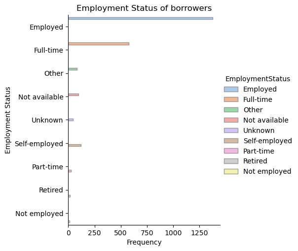

```python
# Plot bar graph for employment status

sns.catplot(
    data=df2, y="EmploymentStatus", hue="EmploymentStatus", kind="count",
    palette="pastel", edgecolor=".6",
)
plt.title('Employment Status of borrowers')
plt.xlabel('Frequency')
plt.ylabel('Employment Status');
```

> The dominant employment type is 'Employed', having over 1250 borrowers. And the second largest emplyment type is 'Full time', having over 500 borrowers. The other employment types fall below 250.

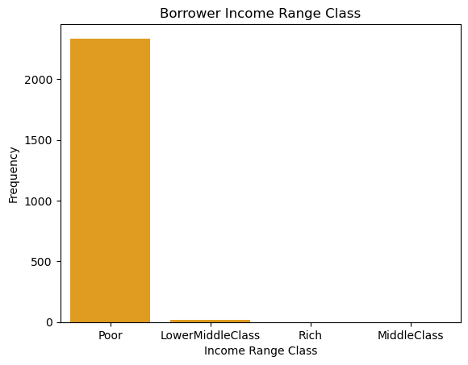

```python
# Plot bar graph for Income Range Class


sns.countplot(data=df2,x='IncomeRangeClass',color='orange')
plt.title('Borrower Income Range Class')
plt.xlabel('Income Range Class')
plt.ylabel('Frequency')
plt.show();
```

> Most loan borrowers (greater than 2000) fall within the 'Poor' Income Range Class. They earn monthly income between 0 - 24999

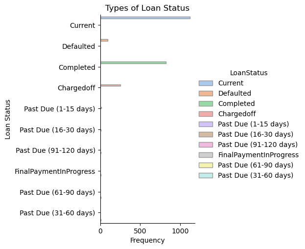

```python
# Plot bar graph for Loan Status


sns.catplot(
    data=df2, y="LoanStatus", hue="LoanStatus", kind="count",
    palette="pastel", edgecolor=".6",
)
plt.title('Types of Loan Status')
plt.xlabel('Frequency')
plt.ylabel('Loan Status')
plt.show(1);
```

> The largest loan status for most borrowers is 'Current'. The number of 'Current' loans is the first largest (greater than 1000), followed by the second largest (greater than 500) 'Completed' loan status. This is followed by 'Charged off' loans (3rd largest) and 'Defaulted' loans (4th largest), which are less than 500.

> Prosper loans has more current loan applications. Regardless of most borrowers falling into the poor income range, they are able to complete payments on their loans as they are fall under either employeed or full-time employment type.

## Quantitative Variable

### How many months has it been since loan origination, How many accounts have delinquencies over the last 7 years, and how many investors are there for each loan

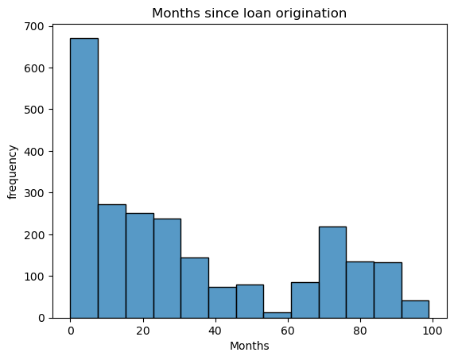

```python
# Plot a histogram for the Loan Months Since Origination

sns.histplot(data=df2, x="LoanMonthsSinceOrigination")
plt.title('Months since loan origination')
plt.xlabel('Months')
plt.ylabel('frequency')
plt.show();
```

> The large number of loans (approximately 680) were originated less than 10 months. The rest of the loans have between àpproximately 11 - 100 months since origination.

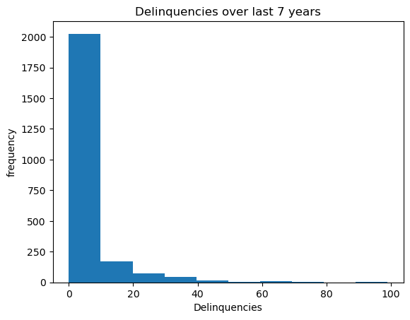

```python
# Histogram Plot for loans that have delinquencies over the last 7 years


plt.hist(data=df2,x='DelinquenciesLast7Years')
plt.title('Delinquencies over last 7 years')
plt.xlabel('Delinquencies')
plt.ylabel('frequency')
plt.show();
```

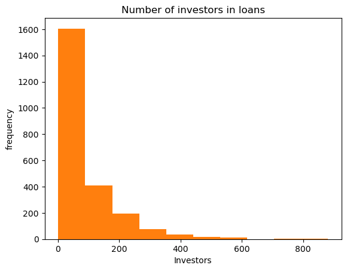

```python
# Histogram Plot for number of investors

plt.hist(data=df2,x='Investors')
plt.title('Number of investors in loans')
plt.xlabel('Investors')
plt.ylabel('frequency')
plt.show();
```

> A lot of loans (approximately 1600) have less than 100 investors. A small number of loans have more 100 investors.

### What are the distribution(s) of the variable(s) of interest. Were there any unusual points? Where any transformations done on the variables?

> > The histograms show that the dataset is positively skewed, meaning that the outliers in the distribution are towards the right.  
> > No I did not transform the data.

### Where there any unusual distributions in the variables that were investigated? Was there any operations on the data to tidy, adjust, or change the form of the data? If so, why?

> I did not want to delete the null values and lose valuable information, so i performed the following operations:
> - The null values in employment status were replaced with a new category called 'Unknown'.
> - The null values in credit rating were replaced with a new category called 'Unknown'.
> - The null values in Delinquencies last 7 year were replaced with random values, which were estimated through interpolation (linear forward interpolation).

> There were some blanks on the previous income range that was originaly in the data, but i noticed that i can use the stated monthly income to get an estimate of the icome range for each borrower, by creating a column called income range class:
> - The income range class, these ranges were created based on the stated monthly income and the income range column that was there before, the classes for the income range were based on the income groups from https://money.usnews.com/money/personal-finance/family-finance/articles/where-do-i-fall-in-the-american-economic-class-system

## Quantitative and Categorical variables

### What was the monthly loan payment per income range class

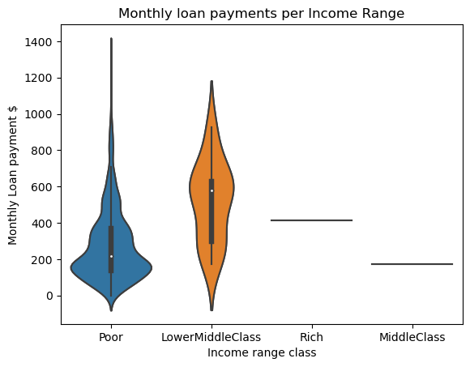

```python
# Plot the violin plot for monthly payment and income range class

sns.violinplot(data=df2,x='IncomeRangeClass',y='MonthlyLoanPayment')
plt.title('Monthly loan payments per Income Range')
plt.xlabel('Income range class')
plt.ylabel('Monthly Loan payment $')
plt.show();
```

> For the poor income range the frequent monthly loan payments are spread around 100 and 200.  
> For the lower middle income class the frequent monthly loan payments are around 500 and 620.  
> For the middle class the monthly loan payments form a straight line corresponding to approximately 180.  
> For the rich income class the monthly loan payments form a straight line corresponding to approximately 400.

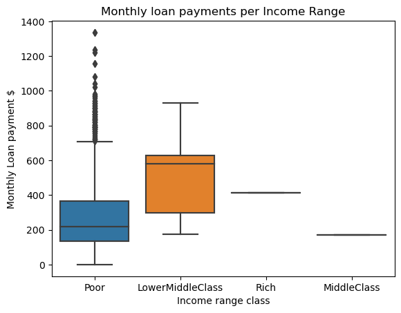

```python
# Plot the box plot for monthly payment and income range class

sns.boxplot(data=df2,x='IncomeRangeClass',y='MonthlyLoanPayment')
plt.title('Monthly loan payments per Income Range')
plt.xlabel('Income range class')
plt.ylabel('Monthly Loan payment $')
plt.show();
```